# DATA622 Assignment 1 (Large and Small Dataset Machine Learning methods and analysis)

Author

Banu & Lucas

Published

October 10, 2024

```r
#Load Packages
library(arrow)
library(dplyr)
library(ggplot2)
library(reshape2)
library(tidymodels)
library(tidyr)
library(broom)
library(patchwork)
library(lubridate)
library(rpart.plot)
library(kableExtra)
library(DataExplorer)
library(skimr)
#install.packages("ranger")
#install.packages("tidymodels")
library(DescTools)
library(corrplot)
library(ggcorrplot)
library(caret)
library(rpart)
library(car)
library(rattle)
library(ROSE)
library(mice)
library(MASS)
library(fpp3)
library(pROC)
```

## Project

### **Deliverable**

1. Explore how to analyze and predict an outcome based on the data available. This will be an exploratory exercise, so feel free to show errors and warnings that raise during the analysis. Test the code with both datasets selected and compare the results.
   1. Are the columns of your data correlated?
   2. Are there labels in your data? Did that impact your choice of algorithm?
   3. What are the pros and cons of each algorithm you selected?
   4. How your choice of algorithm relates to the datasets (was your choice of algorithm impacted by the datasets you chose)?
   5. Which result will you trust if you need to make a business decision?
   6. Do you think an analysis could be prone to errors when using too much data, or when using the least amount possible?
   7. How does the analysis between data sets compare?
2. Essay (minimum 500 word document)  
   Write a short essay explaining your selection of algorithms and how they relate to the data and what you are trying to do

## Essay

Our goal was to understand and work with financial datasets. In line with the goal of this project we selected two large datasets (Credit Card Fraud and Lendingclub Loan). Both classification and regression methods (supervised learning) are good approaches for our datasets since we have availability of labeled samples.

**LendingClub Loan (Fully Paid or Charged Off) Prediction (Large Volume - 300,000+):**

LendingClub loan dataset is provided by Lending Club a peer-to-peer lending firm in San Francisco. Lending loans to risky customers can have a higher impact on credit loss. The dataset above is a good one as it has labeled data on loans that were “Fully Paid” or “Charged Off”. Additionally, this dataset is a rich resource of other categorical potential predictor variables and lends itself well to exploratory data analysis as well as machine learning algorithms such as Logistic regression, RandomForest and Decision Tree models.

https://www.kaggle.com/datasets/jeandedieunyandwi/lending-club-dataset

**Credit Card Fraud (Fraud/Not-Fraud) Prediction (Medium Volume - 200,000+ ):** Fraud activity and customer behavior changes rapidly, causing non-stationary in the transaction data. Fraud represents a small fraction of the daily transactions. We then have a skewed dataset towards the genuine transactions. This yields to a highly imbalanced dataset. Statistical methods such as logistic regression can be applied for fraud detection for classification tasks, however, these are impacted by imbalance of the dataset and can be biased to predicting the majority class. We have also explored decision trees, wherein we can identify rules for predicting the correct class of transactions. We can identify the percentage of instances the condition of rule applies and the accuracy or confidence of a rule, which is predicting correct class of instances in which the condition of the rule applies. We would like to highlight the findings below through exploratory analysis, selection of models to train and then testing on subset of data.

https://data.world/vlad/credit-card-fraud-detection

**Reference thesis with the above dataset:** https://di.ulb.ac.be/map/adalpozz/pdf/Dalpozzolo2015PhD.pdf

**Comparison between the two datasets:**

While both datasets have a large number of records, we have selected the LendingClub loan dataset for our Large dataset for EDA and ML analysis and the Credit Card Fraud as a medium dataset for EDA and ML analysis. Our two datasets above are different in that the credit card fraud dataset is time series data, however the lendingclub loan dataset is not time series related. Therefore, we found the fraud dataset to be higher in complexity since it is time series data. We were able to train on large sample size here (227000+) and then apply the model on the test dataset.

The Lendingclub dataset on the other hand has far more categorical variables than the credit card fraud dataset. We have dived into it further on the exploratory data analysis. Additionally, due to the size of the dataset (300000+ records), we subset the training set from a modeling perspective with data records from issue date of the loan after 2015-01-01. There were challenges in training the data on the higher number of samples, therefore we made a decision to subset the dataset to 100,000 records range and then split it up to train/test set. On this dataset, we were dealing with missing values, decision to drop certain values, review correlated values, additionally during model training, we found train/test split issues and had to ensure all factor levels are present in both train and test datasets.

## Large Data Set (End to End ML Analysis)

### Data set Introduction

The Lendingclub loan data set consists of about 396,030 rows and 27 columns. Even though this dataset is large, we have carved out a subset of records with Time since first credit line > 0 (Time since first credit line is a new engineered variable which is calculated by subtracting the time since first credit line from Issue date of the loan) and Issue date > 2015-01-01 to look at a smaller population to model our dataset.

### Data Exploration & Plots

Several variables are character types and we will be converting those to factors prior to train and test split of the data. The dataset contains missing values recorded for 3 of the variables. We will also consider dropping certain variables such as address. Imputation of the missing values will be handled during data pre-processing step below. Additionally we created a parquet file since it was large volume and stored it on github.

```r
path1 = "https://github.com/BanuB/Card_Transaction_Fraud/raw/refs/heads/master/loandata.parquet"

inputf1 = read_parquet(path1)

#Glimpse variables
introduce(inputf1)
```

```
# A tibble: 1 × 9
    rows columns discrete_columns continuous_columns all_missing_columns
   <int>   <int>            <int>              <int>               <int>
1 396030      27               15                 12                   0
# ℹ 4 more variables: total_missing_values <int>, complete_rows <int>,
#   total_observations <int>, memory_usage <dbl>
```

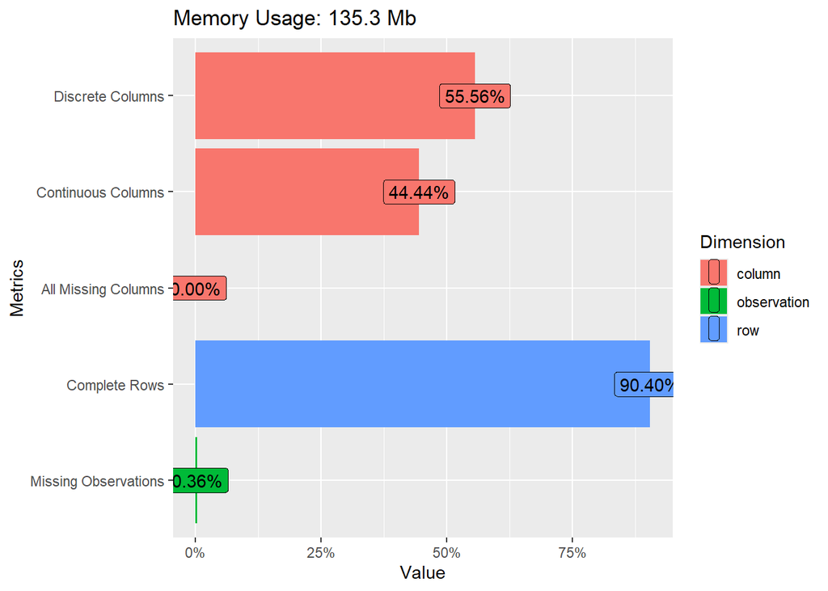

```r
plot_intro(inputf1)
```

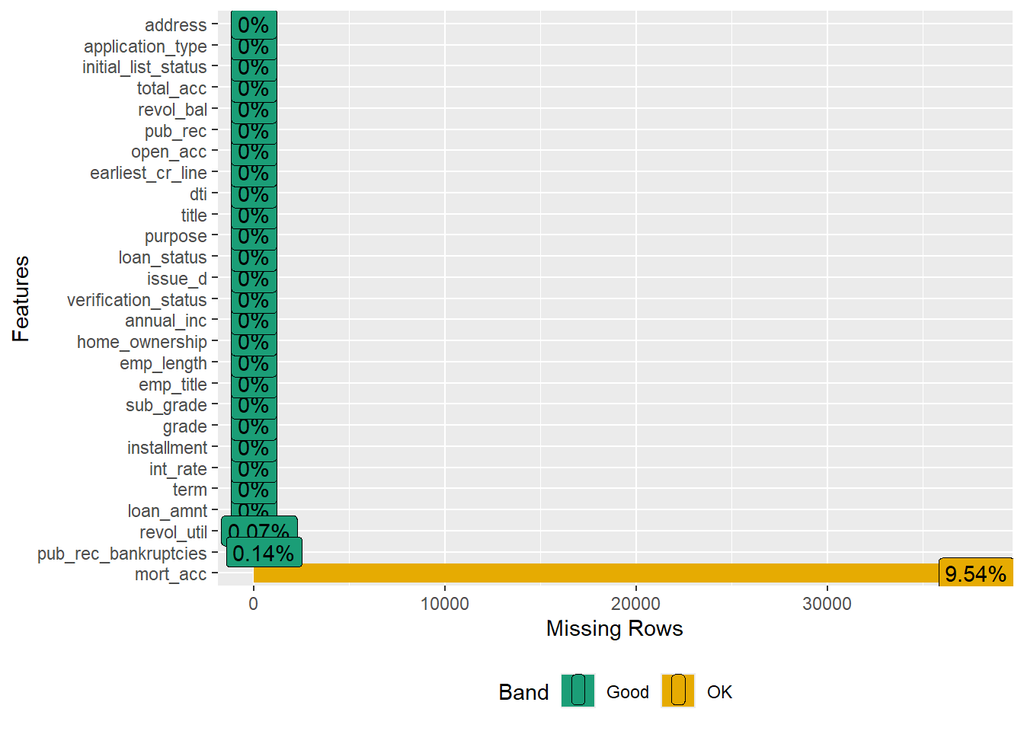

```r
plot_missing(inputf1)
```

```r
glimpse(inputf1)
```

```
Rows: 396,030
Columns: 27
$ loan_amnt            <dbl> 10000, 8000, 15600, 7200, 24375, 20000, 18000, 13…
$ term                 <chr> " 36 months", " 36 months", " 36 months", " 36 mo…
$ int_rate             <dbl> 11.44, 11.99, 10.49, 6.49, 17.27, 13.33, 5.32, 11…
$ installment          <dbl> 329.48, 265.68, 506.97, 220.65, 609.33, 677.07, 5…
$ grade                <chr> "B", "B", "B", "A", "C", "C", "A", "B", "B", "C",…
$ sub_grade            <chr> "B4", "B5", "B3", "A2", "C5", "C3", "A1", "B2", "…
$ emp_title            <chr> "Marketing", "Credit analyst ", "Statistician", "…
$ emp_length           <chr> "10+ years", "4 years", "< 1 year", "6 years", "9…
$ home_ownership       <chr> "RENT", "MORTGAGE", "RENT", "RENT", "MORTGAGE", "…
$ annual_inc           <dbl> 117000, 65000, 43057, 54000, 55000, 86788, 125000…
$ verification_status  <chr> "Not Verified", "Not Verified", "Source Verified"…
$ issue_d              <chr> "Jan-2015", "Jan-2015", "Jan-2015", "Nov-2014", "…
$ loan_status          <chr> "Fully Paid", "Fully Paid", "Fully Paid", "Fully …
$ purpose              <chr> "vacation", "debt_consolidation", "credit_card", …
$ title                <chr> "Vacation", "Debt consolidation", "Credit card re…
$ dti                  <dbl> 26.24, 22.05, 12.79, 2.60, 33.95, 16.31, 1.36, 26…
$ earliest_cr_line     <chr> "Jun-1990", "Jul-2004", "Aug-2007", "Sep-2006", "…
$ open_acc             <dbl> 16, 17, 13, 6, 13, 8, 8, 11, 13, 13, 5, 30, 13, 1…
$ pub_rec              <dbl> 0, 0, 0, 0, 0, 0, 0, 0, 0, 0, 1, 0, 0, 0, 0, 0, 0…
$ revol_bal            <dbl> 36369, 20131, 11987, 5472, 24584, 25757, 4178, 13…
$ revol_util           <dbl> 41.8, 53.3, 92.2, 21.5, 69.8, 100.6, 4.9, 64.5, 3…
$ total_acc            <dbl> 25, 27, 26, 13, 43, 23, 25, 15, 40, 37, 26, 61, 3…
$ initial_list_status  <chr> "w", "f", "f", "f", "f", "f", "f", "f", "w", "f",…
$ application_type     <chr> "INDIVIDUAL", "INDIVIDUAL", "INDIVIDUAL", "INDIVI…
$ mort_acc             <dbl> 0, 3, 0, 0, 1, 4, 3, 0, 3, 1, 4, 4, 4, 2, 6, 4, 1…
$ pub_rec_bankruptcies <dbl> 0, 0, 0, 0, 0, 0, 0, 0, 0, 0, 1, 0, 0, 0, 0, 0, 0…
$ address              <chr> "0174 Michelle Gateway\nMendozaberg, OK 22690", "…
```

```r
unique(inputf1$loan_status)
```

```
[1] "Fully Paid"  "Charged Off"
```

```r
skim(inputf1) %>% kable()
```

| skim_type | skim_variable | n_missing | complete_rate | character.min | character.max | character.empty | character.n_unique | character.whitespace | numeric.mean | numeric.sd | numeric.p0 | numeric.p25 | numeric.p50 | numeric.p75 | numeric.p100 | numeric.hist |
| --- | --- | --- | --- | --- | --- | --- | --- | --- | --- | --- | --- | --- | --- | --- | --- | --- |
| character | term | 0 | 1.0000000 | 10 | 10 | 0 | 2 | 0 | NA | NA | NA | NA | NA | NA | NA | NA |
| character | grade | 0 | 1.0000000 | 1 | 1 | 0 | 7 | 0 | NA | NA | NA | NA | NA | NA | NA | NA |
| character | sub_grade | 0 | 1.0000000 | 2 | 2 | 0 | 35 | 0 | NA | NA | NA | NA | NA | NA | NA | NA |
| character | emp_title | 0 | 1.0000000 | 0 | 78 | 22927 | 173106 | 0 | NA | NA | NA | NA | NA | NA | NA | NA |
| character | emp_length | 0 | 1.0000000 | 0 | 9 | 18301 | 12 | 0 | NA | NA | NA | NA | NA | NA | NA | NA |
| character | home_ownership | 0 | 1.0000000 | 3 | 8 | 0 | 6 | 0 | NA | NA | NA | NA | NA | NA | NA | NA |
| character | verification_status | 0 | 1.0000000 | 8 | 15 | 0 | 3 | 0 | NA | NA | NA | NA | NA | NA | NA | NA |
| character | issue_d | 0 | 1.0000000 | 8 | 8 | 0 | 115 | 0 | NA | NA | NA | NA | NA | NA | NA | NA |
| character | loan_status | 0 | 1.0000000 | 10 | 11 | 0 | 2 | 0 | NA | NA | NA | NA | NA | NA | NA | NA |
| character | purpose | 0 | 1.0000000 | 3 | 18 | 0 | 14 | 0 | NA | NA | NA | NA | NA | NA | NA | NA |
| character | title | 0 | 1.0000000 | 0 | 80 | 1755 | 48818 | 0 | NA | NA | NA | NA | NA | NA | NA | NA |
| character | earliest_cr_line | 0 | 1.0000000 | 8 | 8 | 0 | 684 | 0 | NA | NA | NA | NA | NA | NA | NA | NA |
| character | initial_list_status | 0 | 1.0000000 | 1 | 1 | 0 | 2 | 0 | NA | NA | NA | NA | NA | NA | NA | NA |
| character | application_type | 0 | 1.0000000 | 5 | 10 | 0 | 3 | 0 | NA | NA | NA | NA | NA | NA | NA | NA |
| character | address | 0 | 1.0000000 | 19 | 68 | 0 | 393700 | 0 | NA | NA | NA | NA | NA | NA | NA | NA |
| numeric | loan_amnt | 0 | 1.0000000 | NA | NA | NA | NA | NA | 1.411389e+04 | 8.357441e+03 | 500.00 | 8000.00 | 12000.00 | 20000.00 | 40000.00 | ▆▇▅▂▁ |
| numeric | int_rate | 0 | 1.0000000 | NA | NA | NA | NA | NA | 1.363940e+01 | 4.472157e+00 | 5.32 | 10.49 | 13.33 | 16.49 | 30.99 | ▅▇▅▁▁ |
| numeric | installment | 0 | 1.0000000 | NA | NA | NA | NA | NA | 4.318497e+02 | 2.507278e+02 | 16.08 | 250.33 | 375.43 | 567.30 | 1533.81 | ▇▇▃▁▁ |
| numeric | annual_inc | 0 | 1.0000000 | NA | NA | NA | NA | NA | 7.420318e+04 | 6.163762e+04 | 0.00 | 45000.00 | 64000.00 | 90000.00 | 8706582.00 | ▇▁▁▁▁ |
| numeric | dti | 0 | 1.0000000 | NA | NA | NA | NA | NA | 1.737951e+01 | 1.801909e+01 | 0.00 | 11.28 | 16.91 | 22.98 | 9999.00 | ▇▁▁▁▁ |
| numeric | open_acc | 0 | 1.0000000 | NA | NA | NA | NA | NA | 1.131115e+01 | 5.137649e+00 | 0.00 | 8.00 | 10.00 | 14.00 | 90.00 | ▇▁▁▁▁ |
| numeric | pub_rec | 0 | 1.0000000 | NA | NA | NA | NA | NA | 1.781910e-01 | 5.306706e-01 | 0.00 | 0.00 | 0.00 | 0.00 | 86.00 | ▇▁▁▁▁ |
| numeric | revol_bal | 0 | 1.0000000 | NA | NA | NA | NA | NA | 1.584454e+04 | 2.059184e+04 | 0.00 | 6025.00 | 11181.00 | 19620.00 | 1743266.00 | ▇▁▁▁▁ |
| numeric | revol_util | 276 | 0.9993031 | NA | NA | NA | NA | NA | 5.379175e+01 | 2.445219e+01 | 0.00 | 35.80 | 54.80 | 72.90 | 892.30 | ▇▁▁▁▁ |
| numeric | total_acc | 0 | 1.0000000 | NA | NA | NA | NA | NA | 2.541474e+01 | 1.188699e+01 | 2.00 | 17.00 | 24.00 | 32.00 | 151.00 | ▇▃▁▁▁ |
| numeric | mort_acc | 37795 | 0.9045653 | NA | NA | NA | NA | NA | 1.813991e+00 | 2.147931e+00 | 0.00 | 0.00 | 1.00 | 3.00 | 34.00 | ▇▁▁▁▁ |
| numeric | pub_rec_bankruptcies | 535 | 0.9986491 | NA | NA | NA | NA | NA | 1.216476e-01 | 3.561743e-01 | 0.00 | 0.00 | 0.00 | 0.00 | 8.00 | ▇▁▁▁▁ |

```r
sapply(inputf1, function(x) sum(is.na(x))) %>% kable()
```

|  | x |
| --- | --- |
| loan_amnt | 0 |
| term | 0 |
| int_rate | 0 |
| installment | 0 |
| grade | 0 |
| sub_grade | 0 |
| emp_title | 0 |
| emp_length | 0 |
| home_ownership | 0 |
| annual_inc | 0 |
| verification_status | 0 |
| issue_d | 0 |
| loan_status | 0 |
| purpose | 0 |
| title | 0 |
| dti | 0 |
| earliest_cr_line | 0 |
| open_acc | 0 |
| pub_rec | 0 |
| revol_bal | 0 |
| revol_util | 276 |
| total_acc | 0 |
| initial_list_status | 0 |
| application_type | 0 |
| mort_acc | 37795 |
| pub_rec_bankruptcies | 535 |
| address | 0 |

### Correlation Analysis

Correlation plot reveals that some variables are inter correlated which may not be ideal and can cause unreliable regression estimates.Some steps we can take is combining variables or dropping certain variables. We will consider these later on. For instance total_acc and mort_acc are positively correlated below. Similarly loan_amt and installment have a positive correlation.

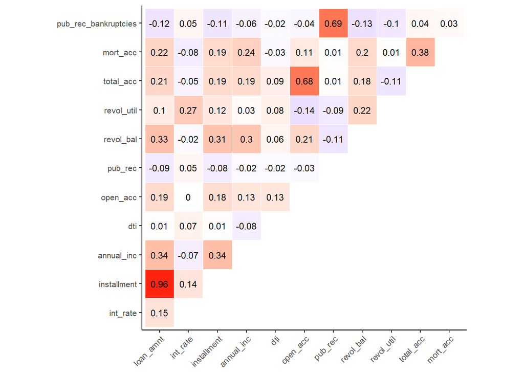

```r
# Select numeric columns only
 numeric_data<- inputf1[sapply(inputf1, is.numeric)]
M<- cor(numeric_data,use="complete.obs")
 # M %>% kable() %>%
 #  kable_styling()

ggcorrplot(M, type = "upper", outline.color = "white",
           ggtheme = theme_classic,
           #colors = c("#6D9EC1", "white", "#E46726"),
           lab = TRUE, show.legend = FALSE, tl.cex = 8, lab_size = 3)
```

```r
# Calculate the correlation matrix
correlation_matrix <- cor(numeric_data, use="complete.obs")
kable(correlation_matrix)
```

|  | loan_amnt | int_rate | installment | annual_inc | dti | open_acc | pub_rec | revol_bal | revol_util | total_acc | mort_acc | pub_rec_bankruptcies |
| --- | --- | --- | --- | --- | --- | --- | --- | --- | --- | --- | --- | --- |
| loan_amnt | 1.0000000 | 0.1467352 | 0.9552040 | 0.3424394 | 0.0080215 | 0.1898158 | -0.0887822 | 0.3273355 | 0.0984388 | 0.2137557 | 0.2223815 | -0.1193732 |
| int_rate | 0.1467352 | 1.0000000 | 0.1401521 | -0.0714182 | 0.0716342 | -0.0037783 | 0.0516314 | -0.0229408 | 0.2733073 | -0.0485737 | -0.0826559 | 0.0485709 |
| installment | 0.9552040 | 0.1401521 | 1.0000000 | 0.3355009 | 0.0059081 | 0.1770997 | -0.0801857 | 0.3148570 | 0.1206656 | 0.1909353 | 0.1937519 | -0.1126934 |
| annual_inc | 0.3424394 | -0.0714182 | 0.3355009 | 1.0000000 | -0.0839820 | 0.1327355 | -0.0161510 | 0.3016988 | 0.0278276 | 0.1877229 | 0.2362765 | -0.0550641 |
| dti | 0.0080215 | 0.0716342 | 0.0059081 | -0.0839820 | 1.0000000 | 0.1253677 | -0.0234581 | 0.0571616 | 0.0795856 | 0.0934558 | -0.0254013 | -0.0201805 |
| open_acc | 0.1898158 | -0.0037783 | 0.1770997 | 0.1327355 | 0.1253677 | 1.0000000 | -0.0297351 | 0.2144474 | -0.1446031 | 0.6777667 | 0.1094396 | -0.0393651 |
| pub_rec | -0.0887822 | 0.0516314 | -0.0801857 | -0.0161510 | -0.0234581 | -0.0297351 | 1.0000000 | -0.1069308 | -0.0893496 | 0.0143639 | 0.0115758 | 0.6946356 |
| revol_bal | 0.3273355 | -0.0229408 | 0.3148570 | 0.3016988 | 0.0571616 | 0.2144474 | -0.1069308 | 1.0000000 | 0.2204292 | 0.1808765 | 0.1950629 | -0.1311621 |
| revol_util | 0.0984388 | 0.2733073 | 0.1206656 | 0.0278276 | 0.0795856 | -0.1446031 | -0.0893496 | 0.2204292 | 1.0000000 | -0.1141447 | 0.0075141 | -0.1020037 |
| total_acc | 0.2137557 | -0.0485737 | 0.1909353 | 0.1877229 | 0.0934558 | 0.6777667 | 0.0143639 | 0.1808765 | -0.1141447 | 1.0000000 | 0.3812052 | 0.0384642 |
| mort_acc | 0.2223815 | -0.0826559 | 0.1937519 | 0.2362765 | -0.0254013 | 0.1094396 | 0.0115758 | 0.1950629 | 0.0075141 | 0.3812052 | 1.0000000 | 0.0272727 |
| pub_rec_bankruptcies | -0.1193732 | 0.0485709 | -0.1126934 | -0.0550641 | -0.0201805 | -0.0393651 | 0.6946356 | -0.1311621 | -0.1020037 | 0.0384642 | 0.0272727 | 1.0000000 |

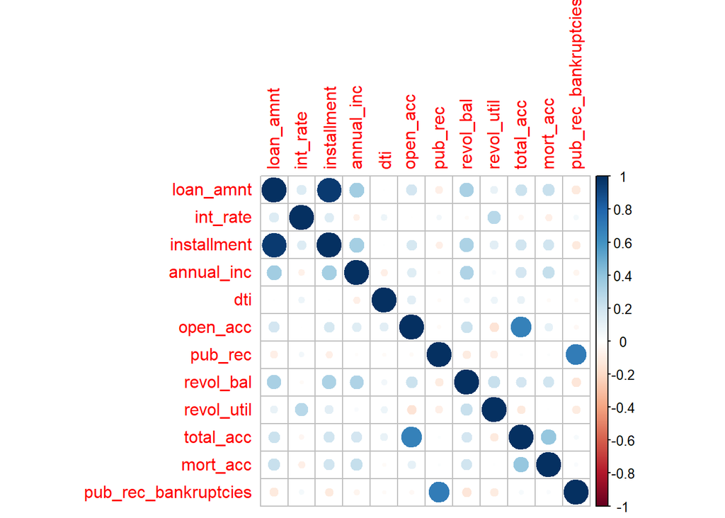

```r
corrplot(correlation_matrix, method="circle")
```

#### Review Distributions

Distributions of factor variables across loan statuses, starting with loan grades. Fully paid loans are at lower interest rates, and charged off loans have a more even distribution, tending towards mid tier interest rates.

```r
loan_stat_df <- subset(inputf1, !is.na(inputf1$loan_status)) %>% group_by(loan_status) %>%
    summarise(Number = n())
loan_stat_df
```

```
# A tibble: 2 × 2
  loan_status Number
  <chr>        <int>
1 Charged Off  77673
2 Fully Paid  318357
```

```r
table(inputf1$loan_status, inputf1$grade)
```

```
                   A      B      C      D      E      F      G
  Charged Off   4036  14587  22449  18338  11765   5037   1461
  Fully Paid   60151 101431  83538  45186  19723   6735   1593
```

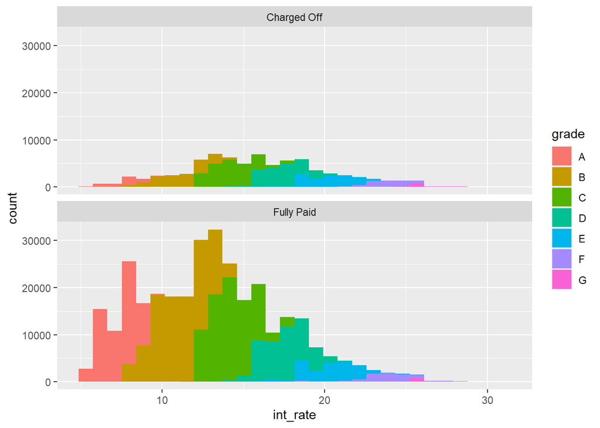

```r
ggplot(inputf1, aes(x = int_rate))+ geom_histogram(aes(fill = grade)) + facet_wrap(~loan_status, ncol = 1)
```

Some additional EDA plots below to show a broader patterns within the data.Loan grades of type E, F, G have higher interest rates.D, E, F, G grade loans also show the presence of high number of outliers. Some of the density plots additionally show not many distributions have a normal bell curve. Additionally several have right skew in the distributions. Loan amount has a 0.78 positive skew value. Also the median loan amount seems to be $12000.00. There are a good number of outliers on higher loan amounts that don’t seem to be verified. Additionally, dataset has upto 59.2% of records of type debt consolidation.

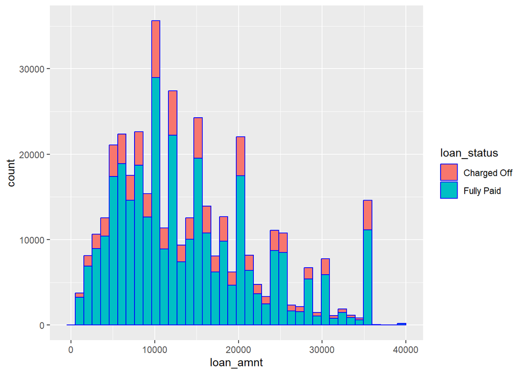

```r
#Loan amt distribution
ggplot(data=inputf1, aes(loan_amnt, fill=loan_status))+geom_histogram(bins = 40,color="blue")
```

```r
str(inputf1)
```

```
tibble [396,030 × 27] (S3: tbl_df/tbl/data.frame)
 $ loan_amnt           : num [1:396030] 10000 8000 15600 7200 24375 ...
 $ term                : chr [1:396030] " 36 months" " 36 months" " 36 months" " 36 months" ...
 $ int_rate            : num [1:396030] 11.44 11.99 10.49 6.49 17.27 ...
 $ installment         : num [1:396030] 329 266 507 221 609 ...
 $ grade               : chr [1:396030] "B" "B" "B" "A" ...
 $ sub_grade           : chr [1:396030] "B4" "B5" "B3" "A2" ...
 $ emp_title           : chr [1:396030] "Marketing" "Credit analyst " "Statistician" "Client Advocate" ...
 $ emp_length          : chr [1:396030] "10+ years" "4 years" "< 1 year" "6 years" ...
 $ home_ownership      : chr [1:396030] "RENT" "MORTGAGE" "RENT" "RENT" ...
 $ annual_inc          : num [1:396030] 117000 65000 43057 54000 55000 ...
 $ verification_status : chr [1:396030] "Not Verified" "Not Verified" "Source Verified" "Not Verified" ...
 $ issue_d             : chr [1:396030] "Jan-2015" "Jan-2015" "Jan-2015" "Nov-2014" ...
 $ loan_status         : chr [1:396030] "Fully Paid" "Fully Paid" "Fully Paid" "Fully Paid" ...
 $ purpose             : chr [1:396030] "vacation" "debt_consolidation" "credit_card" "credit_card" ...
 $ title               : chr [1:396030] "Vacation" "Debt consolidation" "Credit card refinancing" "Credit card refinancing" ...
 $ dti                 : num [1:396030] 26.2 22.1 12.8 2.6 34 ...
 $ earliest_cr_line    : chr [1:396030] "Jun-1990" "Jul-2004" "Aug-2007" "Sep-2006" ...
 $ open_acc            : num [1:396030] 16 17 13 6 13 8 8 11 13 13 ...
 $ pub_rec             : num [1:396030] 0 0 0 0 0 0 0 0 0 0 ...
 $ revol_bal           : num [1:396030] 36369 20131 11987 5472 24584 ...
 $ revol_util          : num [1:396030] 41.8 53.3 92.2 21.5 69.8 ...
 $ total_acc           : num [1:396030] 25 27 26 13 43 23 25 15 40 37 ...
 $ initial_list_status : chr [1:396030] "w" "f" "f" "f" ...
 $ application_type    : chr [1:396030] "INDIVIDUAL" "INDIVIDUAL" "INDIVIDUAL" "INDIVIDUAL" ...
 $ mort_acc            : num [1:396030] 0 3 0 0 1 4 3 0 3 1 ...
 $ pub_rec_bankruptcies: num [1:396030] 0 0 0 0 0 0 0 0 0 0 ...
 $ address             : chr [1:396030] "0174 Michelle Gateway\nMendozaberg, OK 22690" "1076 Carney Fort Apt. 347\nLoganmouth, SD 05113" "87025 Mark Dale Apt. 269\nNew Sabrina, WV 05113" "823 Reid Ford\nDelacruzside, MA 00813" ...
```

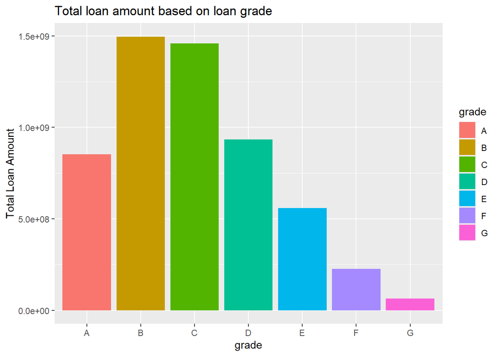

```r
ggplot(inputf1, aes(x=grade, y=loan_amnt, fill=grade)) +
  stat_summary(fun.y="sum", geom="bar") +
  labs(y ="Total Loan Amount",title="Total loan amount based on loan grade")
```

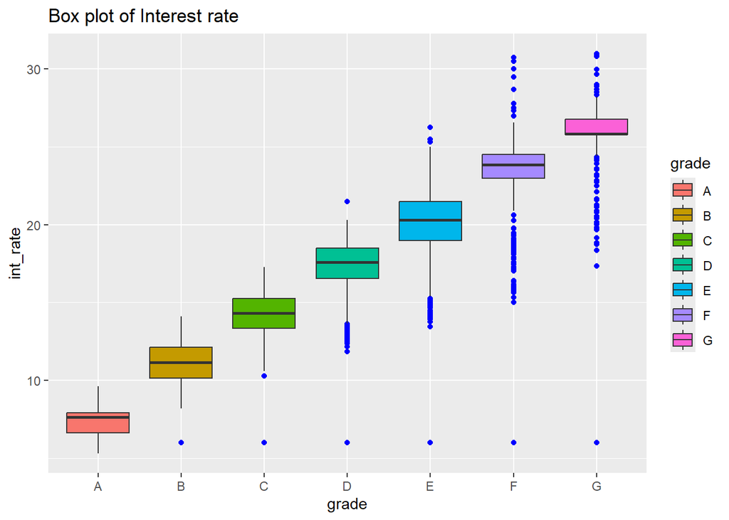

```r
ggplot(data=inputf1, aes(grade,int_rate,fill=grade))+geom_boxplot(outlier.color = "blue")+labs(title="Box plot of Interest rate")
```

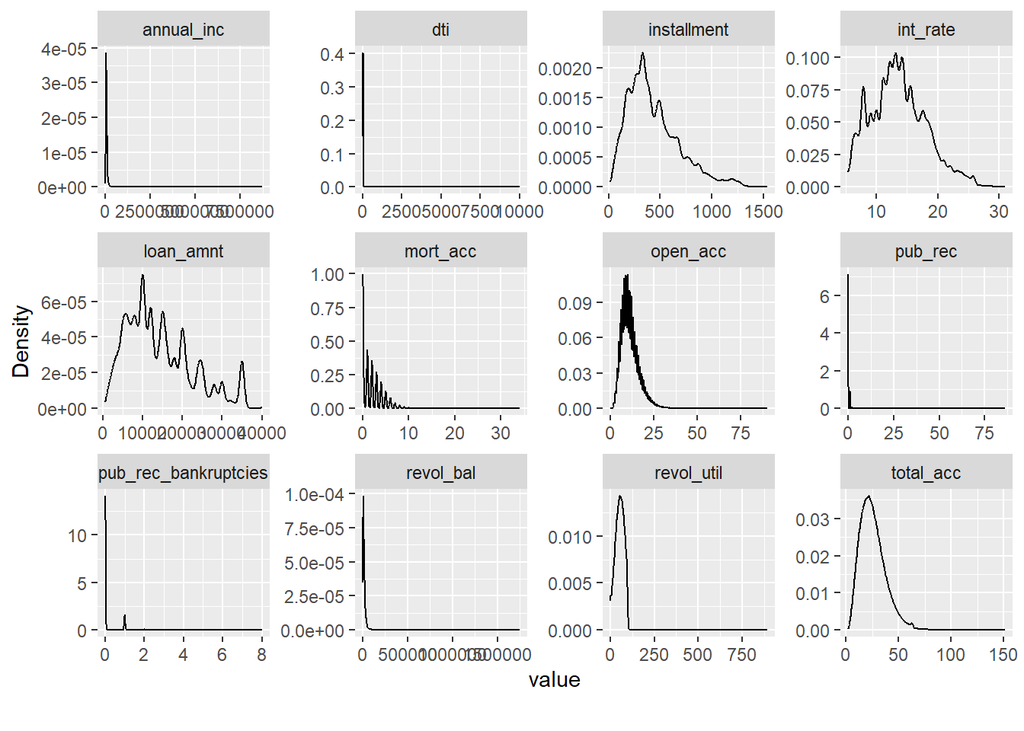

```r
plot_density(inputf1)
```

```
──────────────────────────────────────────────────────────────────────────────
Loan amount distribution

     length         n       NAs     unique         0s       mean     meanCI'
    396'030   396'030         0      1'397          0  14'113.89  14'087.86
               100.0%      0.0%                  0.0%             14'139.92

        .05       .10       .25     median        .75        .90        .95
   3'250.00  5'000.00  8'000.00  12'000.00  20'000.00  26'000.00  30'975.00

      range        sd     vcoef        mad        IQR       skew       kurt
  39'500.00  8'357.44      0.59   8'154.30  12'000.00       0.78      -0.06

lowest : 500.0 (4), 700.0, 725.0, 750.0, 800.0
highest: 39'475.0, 39'500.0, 39'600.0, 39'700.0, 40'000.0 (180)

heap(?): remarkable frequency (7.0%) for the mode(s) (= 10000)

' 95%-CI (classic)
```

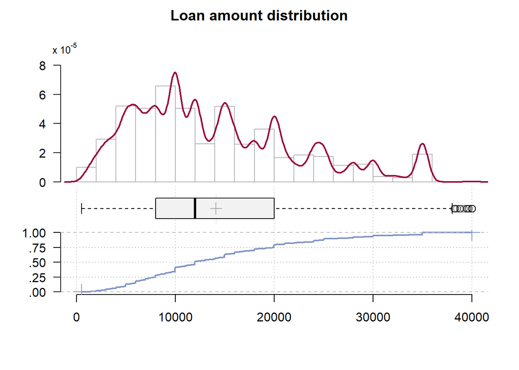

```r
#Distribution of loan amount and purpose
Desc(inputf1$loan_amnt, main = "Loan amount distribution", plotit = TRUE)
```

```
──────────────────────────────────────────────────────────────────────────────
Loan purposes

   length       n     NAs  unique  levels   dupes
  396'030 396'030       0      14      14       y
           100.0%    0.0%

                 level     freq   perc  cumfreq  cumperc
1   debt_consolidation  234'507  59.2%  234'507    59.2%
2          credit_card   83'019  21.0%  317'526    80.2%
3     home_improvement   24'030   6.1%  341'556    86.2%
4                other   21'185   5.3%  362'741    91.6%
5       major_purchase    8'790   2.2%  371'531    93.8%
6       small_business    5'701   1.4%  377'232    95.3%
7                  car    4'697   1.2%  381'929    96.4%
8              medical    4'196   1.1%  386'125    97.5%
9               moving    2'854   0.7%  388'979    98.2%
10            vacation    2'452   0.6%  391'431    98.8%
11               house    2'201   0.6%  393'632    99.4%
12             wedding    1'812   0.5%  395'444    99.9%
... etc.
 [list output truncated]
```

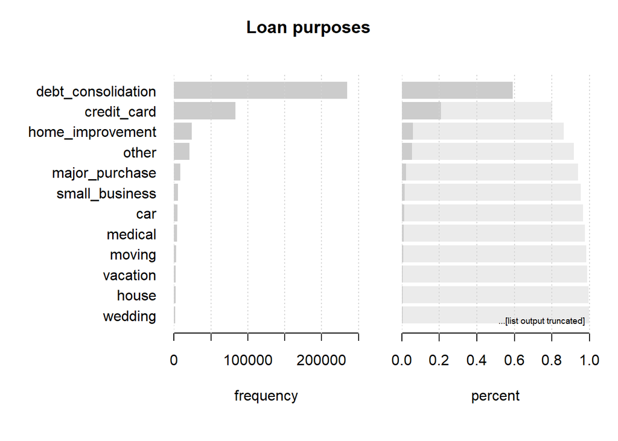

```r
Desc(inputf1$purpose, main = "Loan purposes", plotit = TRUE)
```

```r
#Distribution by verification status
inputf1 %>% group_by(verification_status) %>% summarise(mean(loan_amnt), var(loan_amnt), mean(int_rate),mean(annual_inc))
```

```
# A tibble: 3 × 5
  verification_status `mean(loan_amnt)` `var(loan_amnt)` `mean(int_rate)`
  <chr>                           <dbl>            <dbl>            <dbl>
1 Not Verified                   10415.        32524348.             12.2
2 Source Verified                14765.        67211278.             13.7
3 Verified                       16816.        85819043.             14.8
# ℹ 1 more variable: `mean(annual_inc)` <dbl>
```

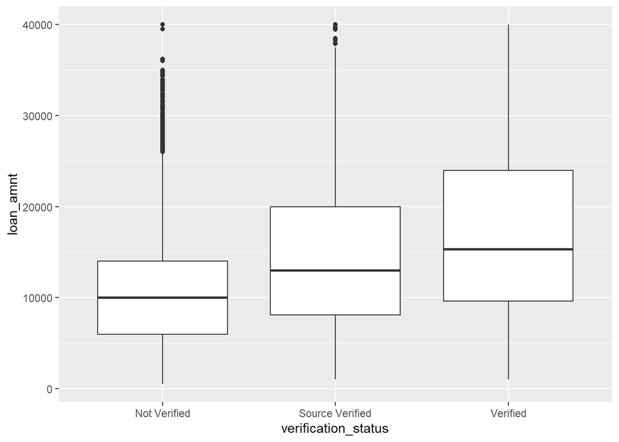

```r
ggplot(data = inputf1,aes(x = verification_status, y = loan_amnt))+geom_boxplot()
```

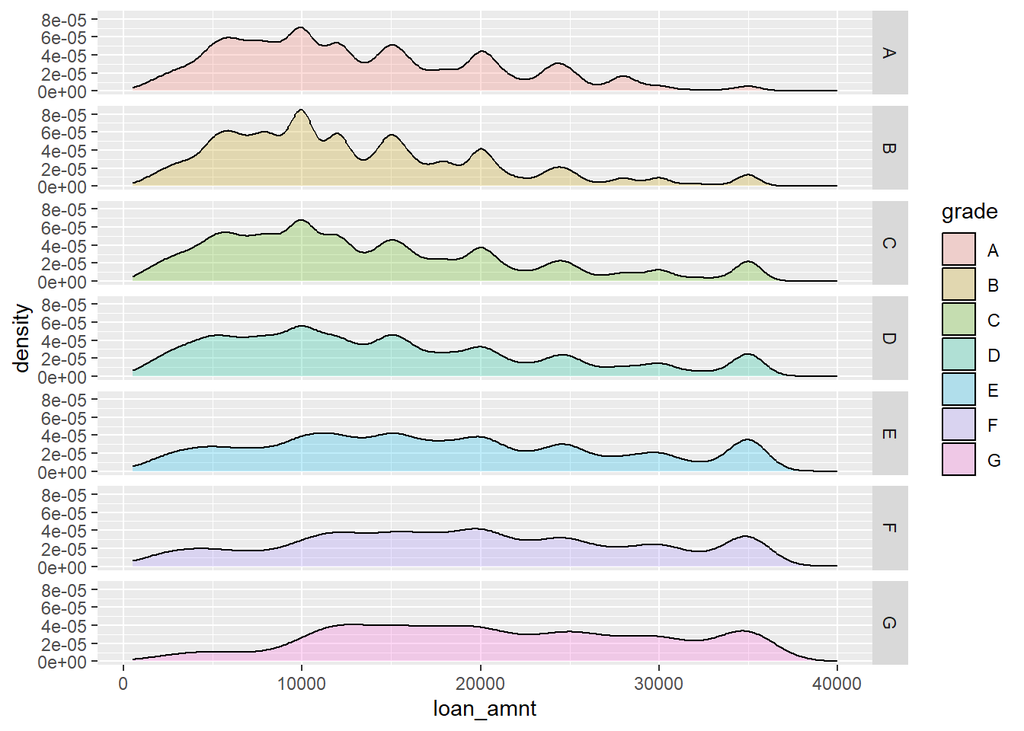

```r
ggplot(data=inputf1,aes(loan_amnt, fill=grade))+
  geom_density(alpha=0.25) +
  facet_grid(grade ~ .)
```

```r
#Distribution of loan status and grade
table(inputf1$loan_status, inputf1$grade)
```

```
                   A      B      C      D      E      F      G
  Charged Off   4036  14587  22449  18338  11765   5037   1461
  Fully Paid   60151 101431  83538  45186  19723   6735   1593
```

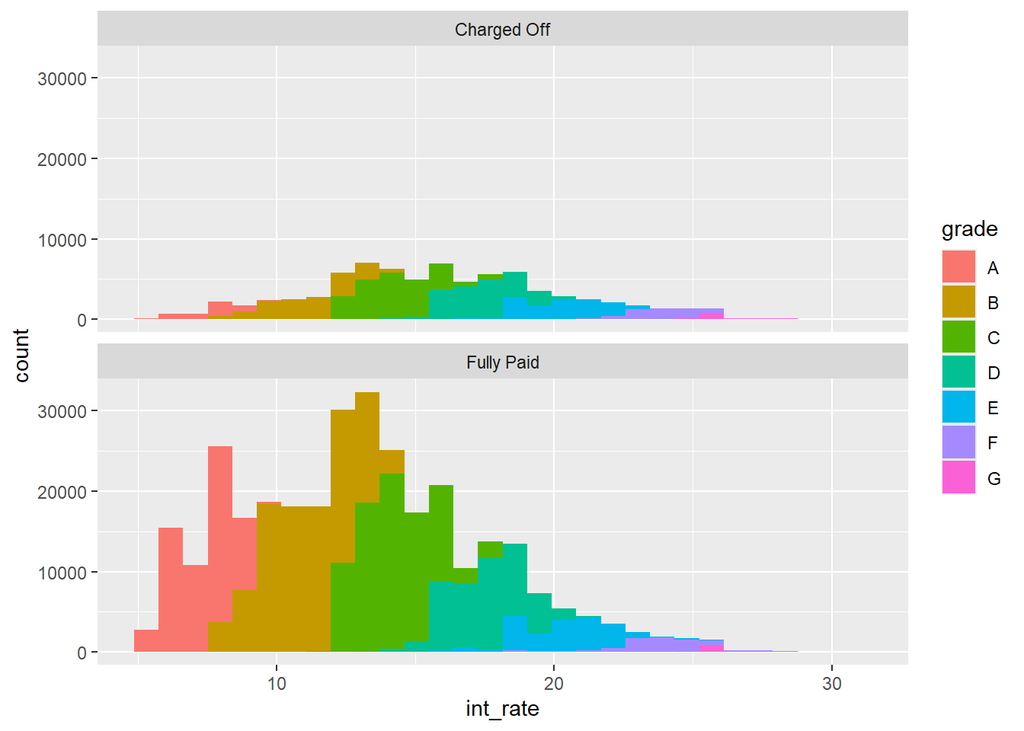

```r
ggplot(inputf1, aes(x = int_rate))+ geom_histogram(aes(fill = grade)) + facet_wrap(~loan_status, ncol = 1)
```

### Data Preparation (Imputation and Feature Engineering)

We have created one additional feature variable called “time since first credit line” was issued to see if there is any impact on the response variable.

```r
# drop address, mort_acc
library(dplyr)
library(gridExtra)
library(grid)
inputf1_new<- dplyr::select(inputf1,-c(mort_acc,address, title, emp_title))
#glimpse(inputf1_new)


inputf1_new %>%
  gather(variable, value) %>%
  filter(is.na(value)) %>%
  group_by(variable) %>%
  tally() %>%
  # dplyr::mutate(percent = (n / nrow(df)) * 100) %>%
  # dplyr::mutate(percent = paste0(round(percent, ifelse(percent < 10, 1, 0)), "%")) %>%
  # arrange(desc(n)) %>%
  rename(`Variable Missing Data` = variable,
         `Number of Records` = n) %>%
      #   `Share of Total` = percent) %>%
  kable() %>%
  kable_styling()
```

| Variable Missing Data | Number of Records |
| --- | --- |
| pub_rec_bankruptcies | 535 |
| revol_util | 276 |

```r
#impute with median
#unique(inputf1_new$pub_rec_bankruptcies)
mean1 <- round(median(inputf1_new$pub_rec_bankruptcies, na.rm = TRUE),0)
inputf1_new[is.na(inputf1_new[,"pub_rec_bankruptcies"]), "pub_rec_bankruptcies"] <- mean1

#impute with mean
mean2 <- round(mean(inputf1_new$revol_util, na.rm = TRUE),0)
inputf1_new[is.na(inputf1_new[,"revol_util"]), "revol_util"] <- mean2
#unique(inputf1_new$revol_util)

#create new variables
inputf1_new$issue_d <- as.character(inputf1_new$issue_d)
inputf1_new$issue_d <- paste(inputf1_new$issue_d, "-01", sep = "")
inputf1_new$issue_d <- parse_date_time(inputf1_new$issue_d, "myd")

inputf1_new$earliest_cr_line <- as.character(inputf1_new$earliest_cr_line)
inputf1_new$earliest_cr_line <- paste(inputf1_new$earliest_cr_line, "-01", sep = "")
inputf1_new$earliest_cr_line <- parse_date_time(inputf1_new$earliest_cr_line, "myd")

inputf1_new$time_since_fcline <- inputf1_new$issue_d - inputf1_new$earliest_cr_line
inputf1_new$time_since_fcline <- as.numeric(inputf1_new$time_since_fcline)

inputf1_new2 <- inputf1_new %>% filter(time_since_fcline > 0 & issue_d > c("2015-01-01 UTC") )
head(inputf1_new2$time_since_fcline)
```

```
[1] 3895 3683 7549 6664 6969 5844
```

```r
loan_stat_df1 <- subset(inputf1_new2, !is.na(inputf1_new2$loan_status)) %>% group_by(loan_status) %>%
    summarise(Number = n())
loan_stat_df1
```

```
# A tibble: 2 × 2
  loan_status Number
  <chr>        <int>
1 Charged Off  24211
2 Fully Paid   86436
```

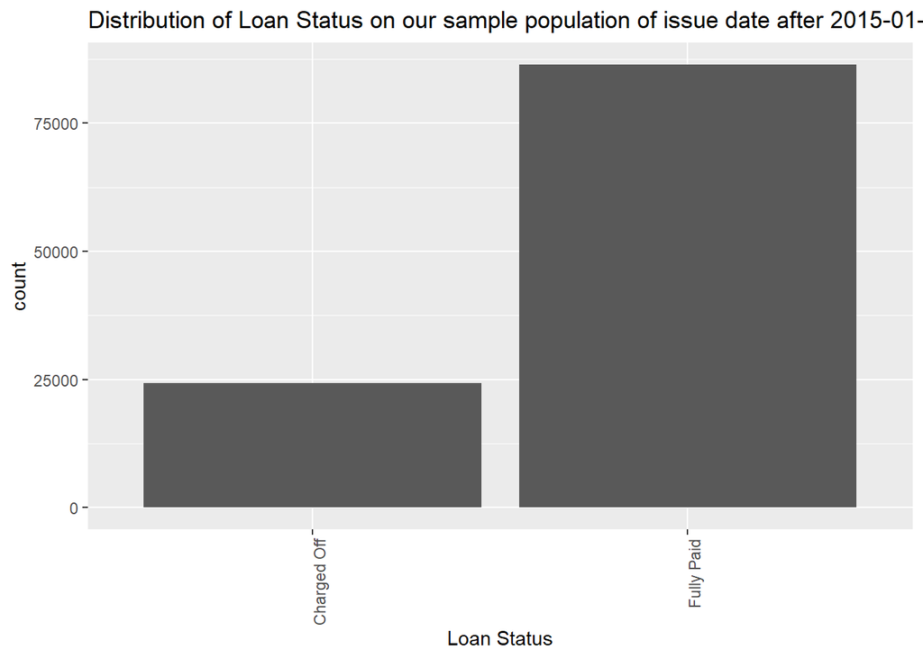

```r
ggplot(data = inputf1_new2 , aes(loan_status)) + geom_bar(position = "dodge") +
    labs(x = "Loan Status", title = "Distribution of Loan Status on our sample population of issue date after 2015-01-01") + theme(axis.text.x = element_text(angle = 90,
    hjust = 1))
```

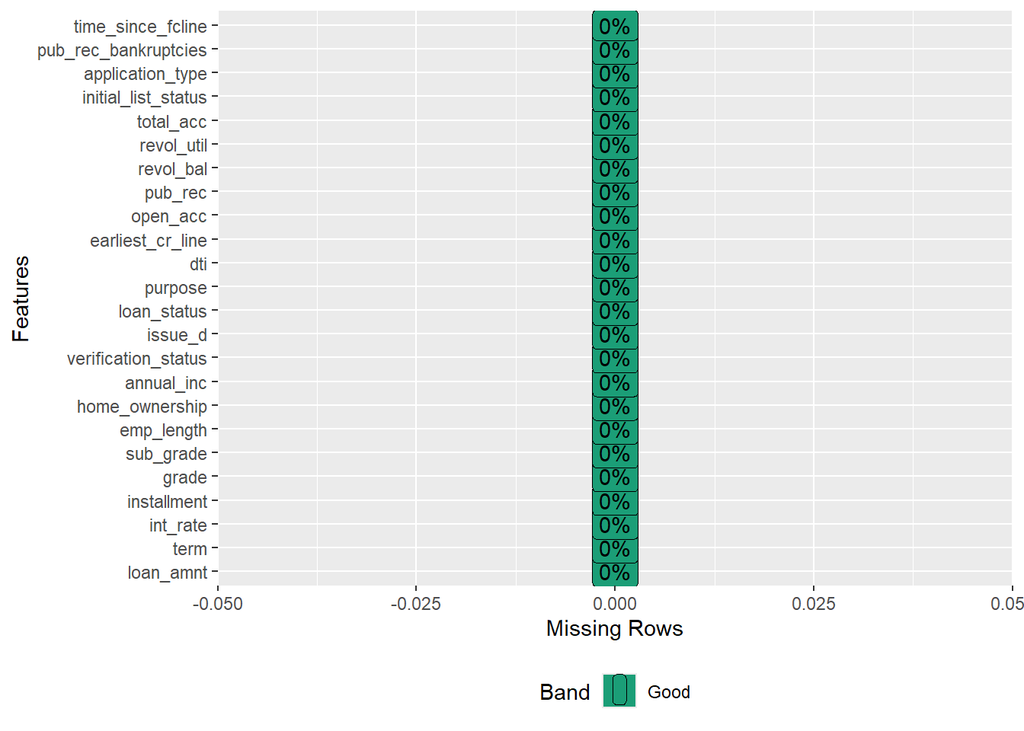

```r
plot_missing(inputf1_new2)
```

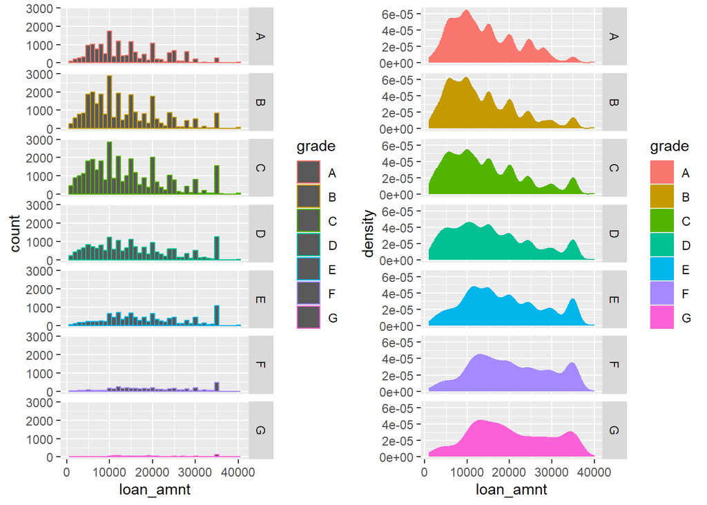

```r
p1 <- ggplot(data = inputf1_new2, aes(loan_amnt, color = grade)) + geom_histogram(binwidth = 1000) +     facet_grid(grade ~ .)
p2 <- ggplot(data = inputf1_new2, aes(loan_amnt, color = grade, fill = grade)) + geom_density(binwidth = 1000) +
    facet_grid(grade ~ .)

grid.arrange(p1, p2, ncol = 2)
```

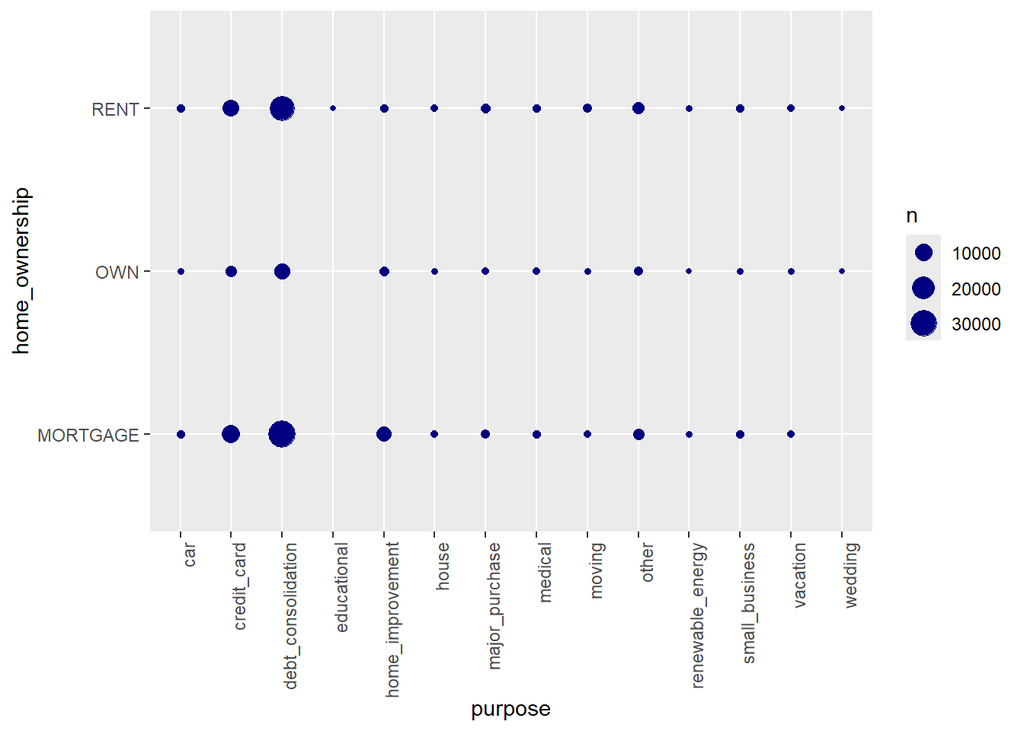

```r
ggplot(data = subset(inputf1_new2, !home_ownership %in% c("ANY", "NONE", "OTHER")), aes(y = home_ownership,
    purpose)) + geom_count(color = "Navy") + theme(axis.text.x = element_text(angle = 90,
    hjust = 1))
```

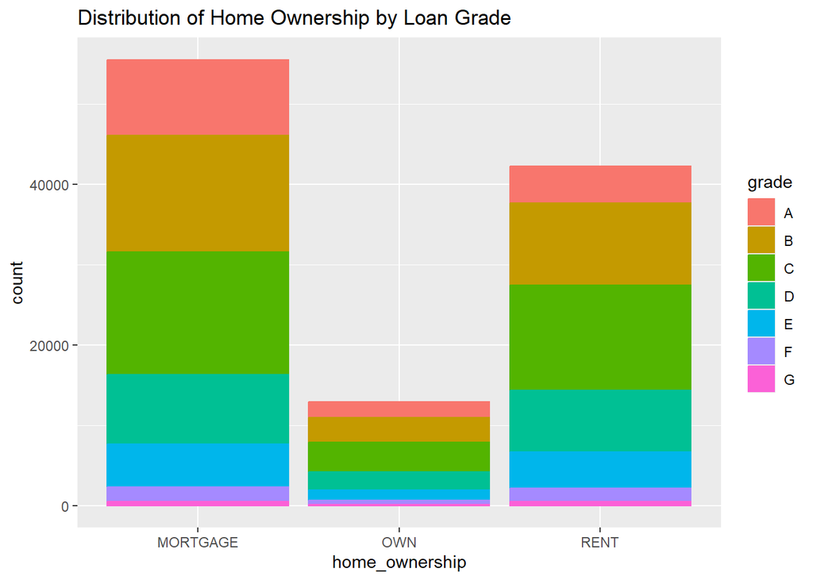

```r
ggplot(data = subset(inputf1_new2, (!is.na(home_ownership) & (!home_ownership %in% c("ANY",
    "NONE", "OTHER")))), aes(home_ownership, fill = grade, color = grade)) +
    geom_bar() + labs(title = "Distribution of Home Ownership by Loan Grade")
```

```r
inputf1_new2 %>% filter(!is.na(purpose)) %>% group_by(purpose) %>% summarise(mean_annual_inc = mean(annual_inc),
    mean_amnt_loan = mean(loan_amnt), n = n()) %>% ungroup() %>% arrange(desc(n))
```

```
# A tibble: 14 × 4
   purpose            mean_annual_inc mean_amnt_loan     n
   <chr>                        <dbl>          <dbl> <int>
 1 debt_consolidation          76042.         15477. 66782
 2 credit_card                 78940.         15553. 21673
 3 home_improvement            95932.         15217.  7839
 4 other                       74409.         10332.  6211
 5 major_purchase              80800.         13112.  2400
 6 medical                     71286.          9173.  1243
 7 car                         68790.          9460.  1104
 8 small_business              96188.         16688.  1036
 9 moving                      71603.          8825.   868
10 vacation                    69324.          6738.   766
11 house                       81944.         15620.   638
12 renewable_energy            69735.          8773.    84
13 wedding                     79000          13350      2
14 educational                 64500           2200      1
```

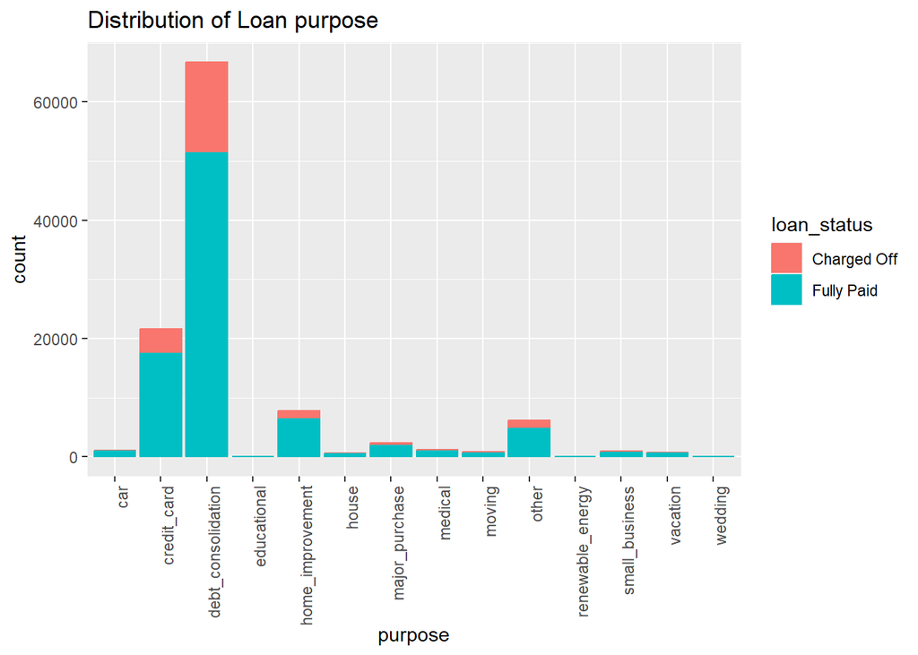

```r
ggplot(data = subset(inputf1_new2, !is.na(purpose)), aes(purpose, fill = loan_status,
    color = loan_status)) + geom_bar() + labs(title = "Distribution of Loan purpose") +
    theme(axis.text.x = element_text(angle = 90, hjust = 1))
```

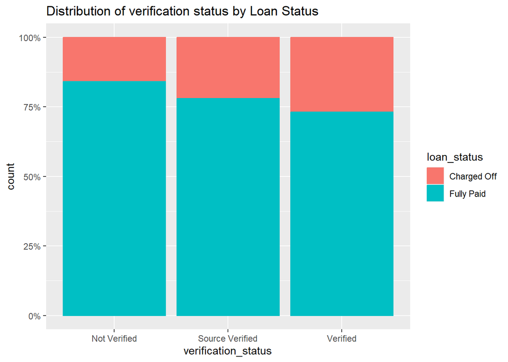

```r
ggplot(data = subset(inputf1_new2, !is.na(verification_status)), aes(verification_status,
    fill = loan_status, color = loan_status)) + geom_bar(position = "fill") +
    labs(title = "Distribution of verification status by Loan Status") + scale_y_continuous(labels = percent_format())
```

Scatter plots in an attempt to identify trends between seemingly related numeric variables.

This one plot suggests that the 60-month loans tend to have larger interest rates and be for larger loan amounts (the top right corner is dominated by blue points).

```r
set.seed(2024)

#dim(inputf1_new2)
#p<-table(inputf1_new2$loan_status, inputf1_new2$int_rate)
#ggplot(inputf1_new2, aes(x = int_rate))+ geom_histogram() + facet_wrap(~loan_status, ncol = 1)

#Distribution of loan status and grade
#table(inputf1_new2$loan_status, inputf1_new2$grade)
#ggplot(inputf1_new2, aes(x = int_rate))+ geom_histogram(aes(fill = grade)) + facet_wrap(~loan_status, ncol = 1)


#Distribution of loan status and term
table(inputf1_new2$loan_status, inputf1_new2$term)
```

```
               36 months  60 months
  Charged Off      14414       9797
  Fully Paid       64470      21966
```

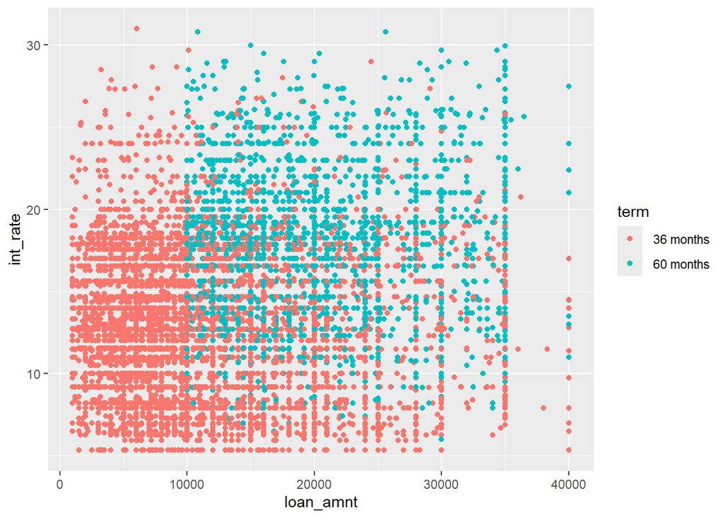

```r
index = createDataPartition(y = inputf1_new2$loan_status, p = 0.90)[[1]]
loans.sample <- inputf1_new2[-index,]
ggplot(loans.sample, aes(x = loan_amnt, y = int_rate)) + geom_point(aes(color = term))
```

### Algorithm Selection/Build Models

### Decision Tree Model and metrics review

For model selection,we have created a partition of the 110,647 records and created 70/30 split of the dataset. The accuracy of our Basic decision tree model is 0.7835.

The Sensitivity (true positive rate) and Specificity (true negative rate) are below for the baseline model.Sensitivity is the metric that evaluates a model’s ability to predict true positives of each available category. Specificity is the metric that evaluates a model’s ability to predict true negatives of each available category.The sensitivity of the model is very low, this implies that the model did not successfully classify the “charged off” loans accurately.Sensitivity : 0.10973 Specificity : 0.97219.

Since our train dataset is highly imbalanced, we can use the ROC curve since we can’t simply use the accuracy measure.Area under the curve (AUC): 0.690. We can try to over, under or combine both sampling method to balance the class prior to running the model to avoid class imbalance issues.

For reference of classification categories of the confusion matrix is given below.

True Positive (TP) – An instance that is positive and is classified correctly as positive True Negative (TN) – An instance that is negative and is classified correctly as negative False Positive (FP) – An instance that is negative but is classified wrongly as positive False Negative (FN) – An instance that is positive but is classified incorrectly as negative

[figure not shown]

```r
#install.packages("RGtk2")

library("rattle")
library(rpart.plot)
library(rpart)
#install.packages("vip")
library(vip)


set.seed(2024)
index = createDataPartition(y = inputf1_new2$loan_status, p = 0.7)[[1]]
loans.test <- inputf1_new2[-index,]
loans.train <- inputf1_new2[index,]


loans.rpart.1 <- rpart(loan_status ~ . , data = loans.train,
                      control=rpart.control(minsplit=10, minbucket = 3, cp=0.0006))

fancyRpartPlot(loans.rpart.1)
```

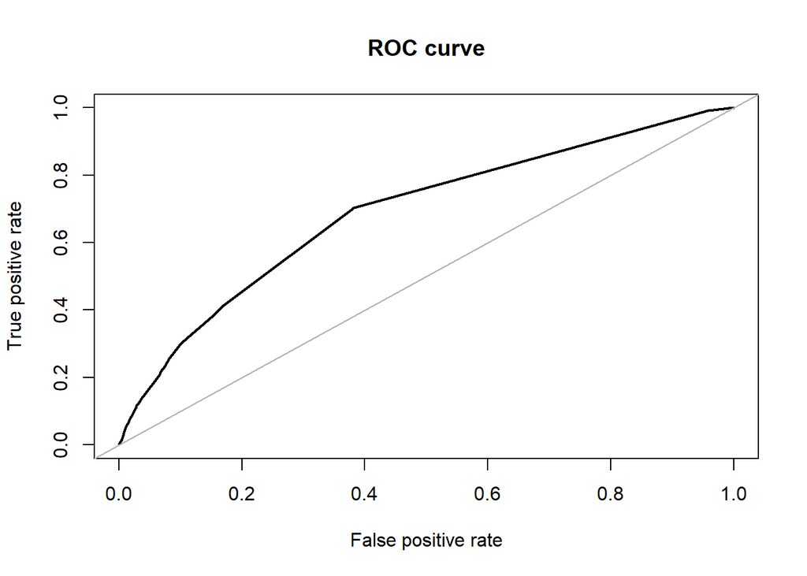

```
Area under the curve (AUC): 0.690
```

```r
predictions.1 <- (predict(loans.rpart.1, loans.test , type = "class"))
p1<-confusionMatrix(predictions.1,as.factor(loans.test$loan_status))
roc.curve(loans.test$loan_status, predict(loans.rpart.1, loans.test, type = "prob")[,1], plot = TRUE)
```

```r
p1
```

```
Confusion Matrix and Statistics

             Reference
Prediction    Charged Off Fully Paid
  Charged Off         797        721
  Fully Paid         6466      25209

               Accuracy : 0.7835
                 95% CI : (0.779, 0.7879)
    No Information Rate : 0.7812
    P-Value [Acc > NIR] : 0.1581

                  Kappa : 0.1145

 Mcnemar's Test P-Value : <2e-16

            Sensitivity : 0.10973
            Specificity : 0.97219
         Pos Pred Value : 0.52503
         Neg Pred Value : 0.79586
             Prevalence : 0.21881
         Detection Rate : 0.02401
   Detection Prevalence : 0.04573
      Balanced Accuracy : 0.54096

       'Positive' Class : Charged Off
```

```r
#rpart.plot(loans.rpart.1, type = 4, extra = 101, under = TRUE, cex = 0.8, box.palette = "auto")
rules<- rpart.rules(loans.rpart.1)
head(rules, 4) %>% kable()
```

|  | loan_status |  |  |  |  |  |  |  |  |  |  |  |  |  |  |  |  |  |  |  |  |  |  |  |  |  |  |  |  | … |
| --- | --- | --- | --- | --- | --- | --- | --- | --- | --- | --- | --- | --- | --- | --- | --- | --- | --- | --- | --- | --- | --- | --- | --- | --- | --- | --- | --- | --- | --- | --- |
| 17466 | 0.00 | when | sub_grade | is | E2 or E3 or E4 or F2 or F3 or F4 or F5 or G1 or G2 or G3 or G5 | & | issue_d | < | 1.4e+09 |  |  | & | dti | is | 20 | to | 30 | & | home_ownership | is | MORTGAGE or OWN | & | emp_length | is | or 10+ years or 2 years or 4 years or 5 years or 6 years or 7 years or 9 years | & | annual_inc | < | 142500 | … |
| 1090 | 0.14 | when | sub_grade | is | E2 or E3 or E4 or F2 or F3 or F4 or F5 or G1 or G2 or G3 or G5 | & | issue_d | < | 1.4e+09 |  |  | & | dti | >= |  |  | 20 | & | home_ownership | is | MORTGAGE or OWN | & | emp_length | is | or 10+ years or 2 years or 4 years or 5 years or 6 years or 7 years or 9 years | & | annual_inc | >= | 142500 | … |
| 1060 | 0.20 | when | sub_grade | is | E3 or E5 or F2 or F3 or F4 or F5 or G1 or G2 or G3 or G4 or G5 | & | issue_d | < | 1.5e+09 |  |  | & | dti | < | 26 |  |  | & | home_ownership | is | RENT | & | emp_length | is | or < 1 year or 1 year or 2 years or 3 years or 4 years | & | annual_inc | < | 96472 | … |
| 2154 | 0.24 | when | sub_grade | is | D3 or D4 or D5 or E1 or E2 or E4 or F1 | & | issue_d | < | 1.4e+09 |  |  | & | dti | < | 26 |  |  | & | home_ownership | is | RENT | & | emp_length | is | < 1 year or 1 year or 10+ years or 5 years or 7 years or 9 years |  |  |  |  | … |

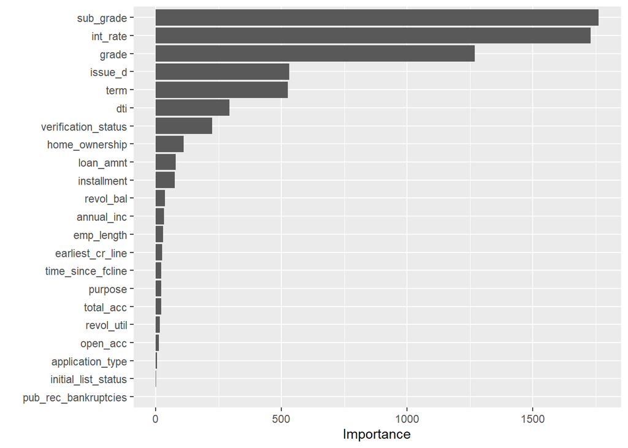

```r
# Create a variable importance plot
var_importance <- vip::vip(loans.rpart.1, num_features = 30)
print(var_importance)
```

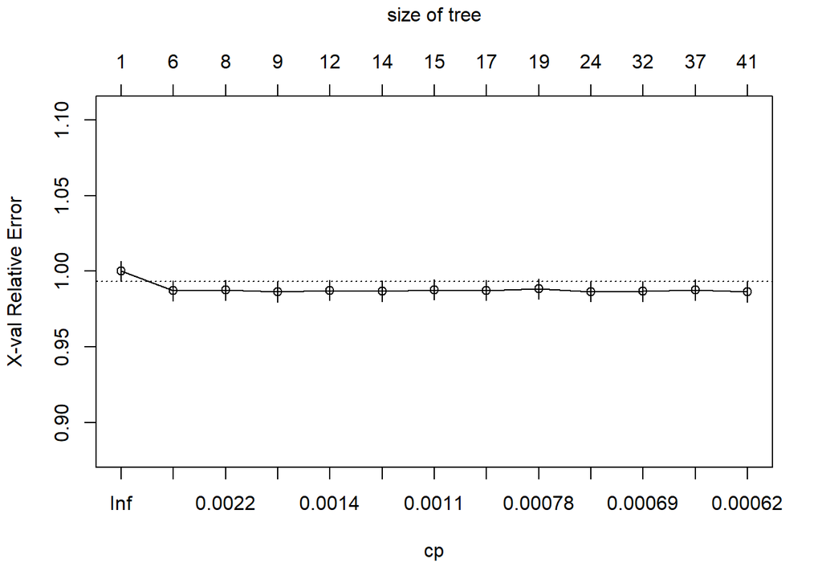

```r
plotcp(loans.rpart.1)
```

```r
costdt <- data.frame(printcp(loans.rpart.1))
```

```
Classification tree:
rpart(formula = loan_status ~ ., data = loans.train, control = rpart.control(minsplit = 10,
    minbucket = 3, cp = 6e-04))

Variables actually used in tree construction:
 [1] annual_inc        dti               emp_length        home_ownership
 [5] installment       issue_d           loan_amnt         open_acc
 [9] purpose           revol_bal         revol_util        sub_grade
[13] time_since_fcline total_acc

Root node error: 16948/77454 = 0.21881

n= 77454

           CP nsplit rel error  xerror      xstd
1  0.00308001      0   1.00000 1.00000 0.0067892
2  0.00271418      5   0.98460 0.98708 0.0067574
3  0.00171112      7   0.97917 0.98749 0.0067584
4  0.00143576      8   0.97746 0.98637 0.0067556
5  0.00135709     11   0.97315 0.98737 0.0067581
6  0.00118008     13   0.97044 0.98678 0.0067566
7  0.00106207     14   0.96926 0.98779 0.0067591
8  0.00082606     16   0.96713 0.98743 0.0067583
9  0.00073755     18   0.96548 0.98838 0.0067606
10 0.00070805     23   0.96177 0.98655 0.0067561
11 0.00067855     31   0.95545 0.98672 0.0067565
12 0.00064904     36   0.95191 0.98761 0.0067587
13 0.00060000     40   0.94932 0.98649 0.0067559
```

```r
min_err <- (costdt  %>% filter(nsplit > 1) %>% slice(which.min(xerror)))$CP
cat("Minimum Error: ", min_err)
```

```
Minimum Error:  0.001435764
```

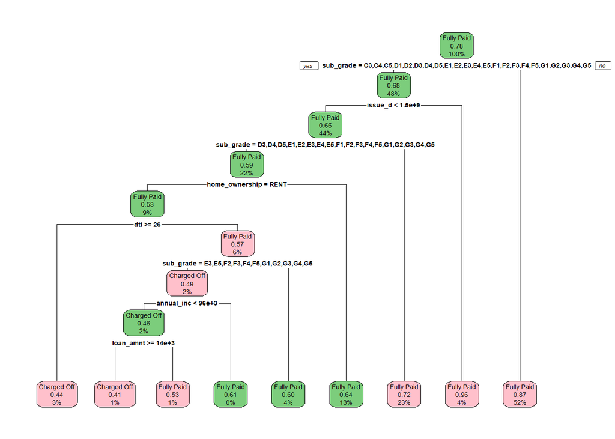

```r
loan_prune <- rpart::prune(loans.rpart.1,min_err)
rpart.plot(loan_prune, box.col = c("pink", "palegreen3")[loans.rpart.1$frame$yval])
```

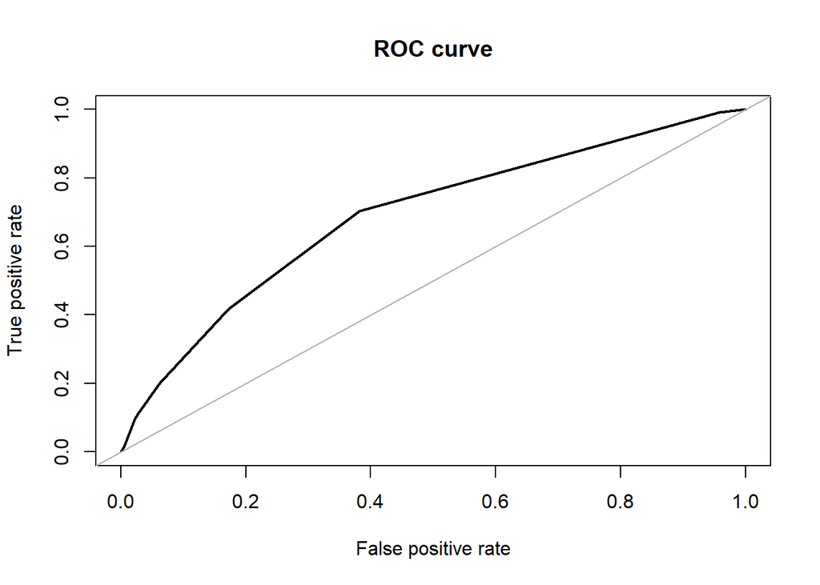

```
Area under the curve (AUC): 0.689
```

```r
loan_prune_pred <- predict(loan_prune, loans.test, type = "class")
#prunedcm <- confusionMatrix(loan_prune_pred, as.factor(loans.test$loan_Status))
# dt_pruned_cm$table

roc.curve(loans.test$loan_status, predict(loan_prune, loans.test, type = "prob")[,1], plot = TRUE)
```

```r
p1
```

```
Confusion Matrix and Statistics

             Reference
Prediction    Charged Off Fully Paid
  Charged Off         797        721
  Fully Paid         6466      25209

               Accuracy : 0.7835
                 95% CI : (0.779, 0.7879)
    No Information Rate : 0.7812
    P-Value [Acc > NIR] : 0.1581

                  Kappa : 0.1145

 Mcnemar's Test P-Value : <2e-16

            Sensitivity : 0.10973
            Specificity : 0.97219
         Pos Pred Value : 0.52503
         Neg Pred Value : 0.79586
             Prevalence : 0.21881
         Detection Rate : 0.02401
   Detection Prevalence : 0.04573
      Balanced Accuracy : 0.54096

       'Positive' Class : Charged Off
```

```r
rules<- rpart.rules(loan_prune)
head(rules) %>% kable()
```

|  | loan_status |  |  |  |  |  |  |  |  |  |  |  |  |  |  |  |  |  |  |  |  |  |  |  |  |
| --- | --- | --- | --- | --- | --- | --- | --- | --- | --- | --- | --- | --- | --- | --- | --- | --- | --- | --- | --- | --- | --- | --- | --- | --- | --- |
| 264 | 0.41 | when | sub_grade | is | E3 or E5 or F2 or F3 or F4 or F5 or G1 or G2 or G3 or G4 or G5 | & | issue_d | < | 1.5e+09 | & | home_ownership | is | RENT | & | dti | < | 26 | & | annual_inc | < | 96472 | & | loan_amnt | >= | 14413 |
| 32 | 0.44 | when | sub_grade | is | D3 or D4 or D5 or E1 or E2 or E3 or E4 or E5 or F1 or F2 or F3 or F4 or F5 or G1 or G2 or G3 or G4 or G5 | & | issue_d | < | 1.5e+09 | & | home_ownership | is | RENT | & | dti | >= | 26 |  |  |  |  |  |  |  |  |
| 265 | 0.53 | when | sub_grade | is | E3 or E5 or F2 or F3 or F4 or F5 or G1 or G2 or G3 or G4 or G5 | & | issue_d | < | 1.5e+09 | & | home_ownership | is | RENT | & | dti | < | 26 | & | annual_inc | < | 96472 | & | loan_amnt | < | 14413 |
| 67 | 0.60 | when | sub_grade | is | D3 or D4 or D5 or E1 or E2 or E4 or F1 | & | issue_d | < | 1.5e+09 | & | home_ownership | is | RENT | & | dti | < | 26 |  |  |  |  |  |  |  |  |
| 133 | 0.61 | when | sub_grade | is | E3 or E5 or F2 or F3 or F4 or F5 or G1 or G2 or G3 or G4 or G5 | & | issue_d | < | 1.5e+09 | & | home_ownership | is | RENT | & | dti | < | 26 | & | annual_inc | >= | 96472 |  |  |  |  |
| 17 | 0.64 | when | sub_grade | is | D3 or D4 or D5 or E1 or E2 or E3 or E4 or E5 or F1 or F2 or F3 or F4 or F5 or G1 or G2 or G3 or G4 or G5 | & | issue_d | < | 1.5e+09 | & | home_ownership | is | MORTGAGE or OWN |  |  |  |  |  |  |  |  |  |  |  |  |

### Oversampling and fixing class imbalance and rerunning decision tree model.

We have tried over sample/under sample and combined with “Both” option on the train dataset to see if we can fix the class imbalance. The resulting model has jumped in sensitivity, however, it has misclassified large # of records as charged off when they were full paid. We will need to try to understand why this maybe potentially as a follow-up to this project.

```r
set.seed(2024)

glimpse(loans.train)
```

```
Rows: 77,454
Columns: 24
$ loan_amnt            <dbl> 20000, 18000, 35000, 20000, 5000, 4600, 21000, 67…
$ term                 <chr> " 36 months", " 36 months", " 60 months", " 36 mo…
$ int_rate             <dbl> 13.33, 5.32, 12.29, 6.97, 15.61, 12.29, 17.86, 21…
$ installment          <dbl> 677.07, 542.07, 783.70, 617.27, 174.83, 153.43, 5…
$ grade                <chr> "C", "A", "C", "A", "D", "C", "D", "D", "A", "D",…
$ sub_grade            <chr> "C3", "A1", "C1", "A3", "D1", "C1", "D5", "D5", "…
$ emp_length           <chr> "10+ years", "2 years", "10+ years", "7 years", "…
$ home_ownership       <chr> "MORTGAGE", "MORTGAGE", "MORTGAGE", "MORTGAGE", "…
$ annual_inc           <dbl> 86788, 125000, 157000, 85000, 75000, 29400, 80000…
$ verification_status  <chr> "Verified", "Source Verified", "Verified", "Not V…
$ issue_d              <dttm> 2015-09-01, 2015-09-01, 2015-04-01, 2016-03-01, …
$ loan_status          <chr> "Fully Paid", "Fully Paid", "Fully Paid", "Fully …
$ purpose              <chr> "debt_consolidation", "home_improvement", "debt_c…
$ dti                  <dbl> 16.31, 1.36, 29.39, 18.80, 13.58, 29.63, 15.67, 1…
$ earliest_cr_line     <dttm> 2005-01-01, 2005-08-01, 1997-01-01, 2000-03-01, …
$ open_acc             <dbl> 8, 8, 17, 15, 9, 12, 15, 15, 7, 18, 11, 10, 14, 2…
$ pub_rec              <dbl> 0, 0, 0, 0, 0, 0, 0, 0, 0, 0, 0, 0, 0, 0, 0, 0, 0…
$ revol_bal            <dbl> 25757, 4178, 113091, 24195, 3120, 10112, 4189, 58…
$ revol_util           <dbl> 100.6, 4.9, 94.9, 55.7, 19.1, 65.7, 13.0, 14.7, 9…
$ total_acc            <dbl> 23, 25, 27, 38, 26, 17, 35, 21, 18, 23, 29, 23, 2…
$ initial_list_status  <chr> "f", "f", "w", "w", "f", "w", "w", "w", "w", "w",…
$ application_type     <chr> "INDIVIDUAL", "INDIVIDUAL", "INDIVIDUAL", "INDIVI…
$ pub_rec_bankruptcies <dbl> 0, 0, 0, 0, 0, 0, 0, 0, 0, 0, 0, 0, 0, 0, 0, 0, 0…
$ time_since_fcline    <dbl> 3895, 3683, 6664, 5844, 2679, 2772, 5051, 2009, 7…
```

```r
glimpse(loans.test)
```

```
Rows: 33,193
Columns: 24
$ loan_amnt            <dbl> 7500, 11200, 20000, 12000, 15000, 8050, 35000, 84…
$ term                 <chr> " 36 months", " 60 months", " 36 months", " 60 mo…
$ int_rate             <dbl> 9.17, 12.29, 12.29, 8.18, 18.55, 16.55, 14.65, 6.…
$ installment          <dbl> 239.10, 250.79, 667.06, 244.36, 385.41, 285.21, 1…
$ grade                <chr> "B", "C", "C", "B", "E", "D", "C", "A", "C", "B",…
$ sub_grade            <chr> "B2", "C1", "C1", "B1", "E2", "D2", "C5", "A4", "…
$ emp_length           <chr> "7 years", "10+ years", "3 years", "7 years", "3 …
$ home_ownership       <chr> "OWN", "MORTGAGE", "RENT", "MORTGAGE", "RENT", "R…
$ annual_inc           <dbl> 55000, 81000, 95000, 60000, 50000, 29500, 95000, …
$ verification_status  <chr> "Not Verified", "Not Verified", "Source Verified"…
$ issue_d              <dttm> 2015-12-01, 2015-10-01, 2015-06-01, 2015-04-01, …
$ loan_status          <chr> "Fully Paid", "Fully Paid", "Fully Paid", "Charge…
$ purpose              <chr> "debt_consolidation", "debt_consolidation", "debt…
$ dti                  <dbl> 28.21, 12.87, 11.82, 20.34, 4.22, 28.23, 13.20, 6…
$ earliest_cr_line     <dttm> 1995-04-01, 1996-09-01, 2007-10-01, 2002-02-01, …
$ open_acc             <dbl> 13, 6, 11, 7, 6, 9, 10, 5, 14, 5, 13, 13, 4, 8, 1…
$ pub_rec              <dbl> 0, 1, 0, 0, 0, 0, 0, 2, 1, 0, 1, 1, 0, 0, 0, 1, 1…
$ revol_bal            <dbl> 17838, 5874, 16498, 21750, 8912, 3327, 15437, 602…
$ revol_util           <dbl> 54.9, 54.9, 54.1, 59.9, 47.9, 39.6, 42.1, 76.3, 7…
$ total_acc            <dbl> 35, 20, 17, 20, 23, 12, 25, 12, 19, 16, 18, 46, 2…
$ initial_list_status  <chr> "w", "w", "f", "w", "f", "w", "w", "f", "w", "f",…
$ application_type     <chr> "JOINT", "INDIVIDUAL", "INDIVIDUAL", "INDIVIDUAL"…
$ pub_rec_bankruptcies <dbl> 0, 1, 0, 0, 0, 0, 0, 1, 0, 0, 0, 1, 0, 0, 0, 1, 1…
$ time_since_fcline    <dbl> 7549, 6969, 2800, 4807, 4230, 4807, 6604, 4171, 8…
```

```r
loans.oversample <- ovun.sample(loan_status ~ ., data = loans.train, method = "both",N = 77454, seed = 13)$data
table(loans.oversample$loan_status)
```

```
Charged Off  Fully Paid
      38861       38593
```

```r
table(loans.train$loan_status)
```

```
Charged Off  Fully Paid
      16948       60506
```

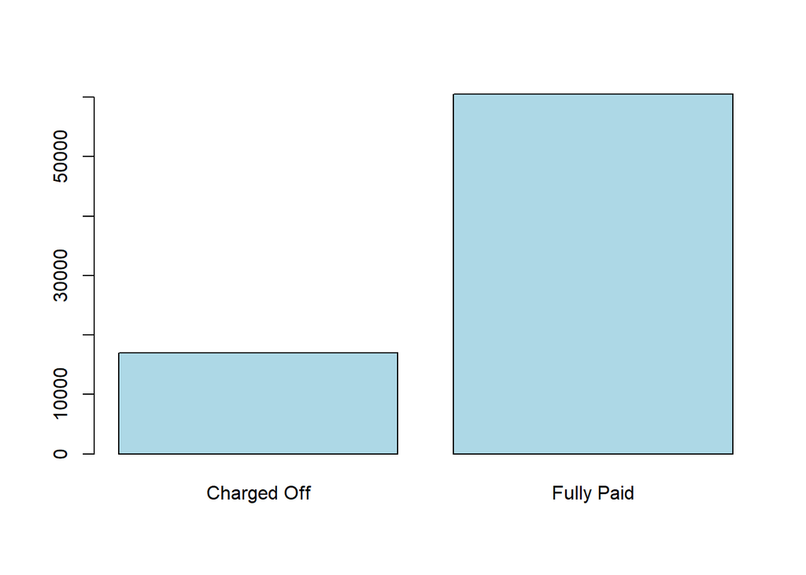

```r
barplot(table(loans.train$loan_status) , col = 'lightblue')
```

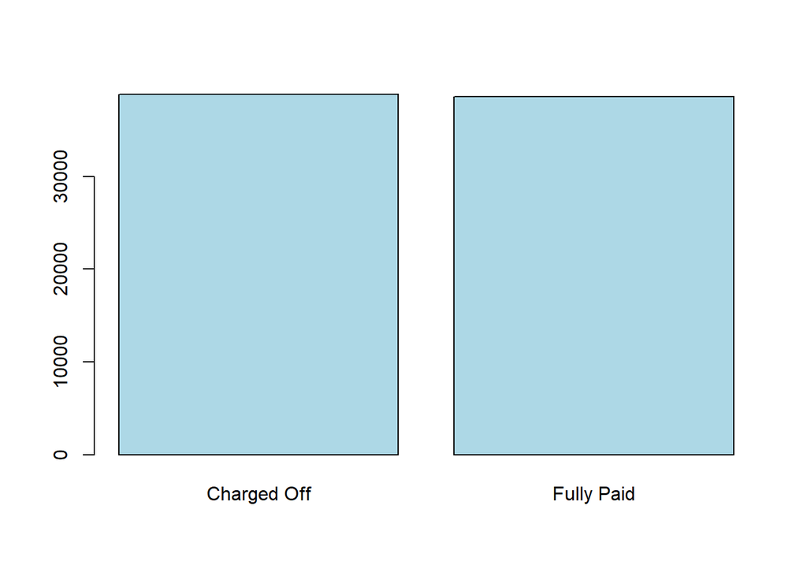

```r
barplot(table(loans.oversample$loan_status) , col = 'lightblue')
```

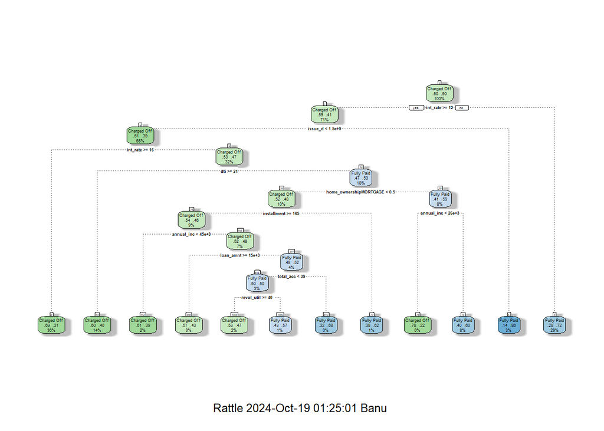

```r
tune <- data.frame(0.001)
colnames(tune) <- "cp"
tr_control <- trainControl(method = "cv",number = 10, verboseIter = TRUE)
loans.over <- train(loan_status ~., data = loans.oversample, method = "rpart", trControl = tr_control, tuneGrid = tune, control=rpart.control(minsplit=10, minbucket = 3))
fancyRpartPlot(loans.over$finalModel)
```

```r
confusionMatrix(predict(loans.over, loans.test), as.factor(loans.test$loan_status))
```

```
Confusion Matrix and Statistics

             Reference
Prediction    Charged Off Fully Paid
  Charged Off        5458      10640
  Fully Paid         1805      15290

               Accuracy : 0.6251
                 95% CI : (0.6198, 0.6303)
    No Information Rate : 0.7812
    P-Value [Acc > NIR] : 1

                  Kappa : 0.2373

 Mcnemar's Test P-Value : <2e-16

            Sensitivity : 0.7515
            Specificity : 0.5897
         Pos Pred Value : 0.3390
         Neg Pred Value : 0.8944
             Prevalence : 0.2188
         Detection Rate : 0.1644
   Detection Prevalence : 0.4850
      Balanced Accuracy : 0.6706

       'Positive' Class : Charged Off
```

### Logistic Regression (Train Data set)

```r
loans.oversample1 <- loans.oversample %>% mutate(loan_outcome = ifelse(loan_status %in% c('Charged Off' , 'Default') , 1, ifelse(loan_status == 'Fully Paid' , 0 , 'No info')))

loans.oversample1 <- loans.oversample1[, colnames(loans.oversample1)[colnames(loans.oversample1) != 'loan_status']]


loans.oversample1 <- loans.oversample1[, colnames(loans.oversample1)[colnames(loans.oversample1) != 'issue_d']]

loans.oversample1 <- loans.oversample1[, colnames(loans.oversample1)[colnames(loans.oversample1) != 'earliest_cr_line']]

factorize = function(column, df){
  #' Check if column is character and  turn to factor

  if(class(df[1,column]) == "character"){
    out = as.factor(df[,column])
  } else { # if it's numeric
    out = df[,column]
  }
  return(out)
}

# str(loans.oversample)
# str(loans.oversample1)
# class(loans.oversample1[1,"term"])
store.colnames = colnames(loans.oversample1)
loans.oversample3  = lapply(store.colnames, function(column) factorize(column, loans.oversample1))
loans.oversample3= as.data.frame(loans.oversample3 )
colnames(loans.oversample3)=store.colnames


full.reg <- glm(loan_outcome ~ ., data =loans.oversample3, family = "binomial")
loans.reg  <- stepAIC(full.reg, direction = "both")
```

```
Start:  AIC=93592.09
loan_outcome ~ loan_amnt + term + int_rate + installment + grade +
    sub_grade + emp_length + home_ownership + annual_inc + verification_status +
    purpose + dti + open_acc + pub_rec + revol_bal + revol_util +
    total_acc + initial_list_status + application_type + pub_rec_bankruptcies +
    time_since_fcline


Step:  AIC=93592.09
loan_outcome ~ loan_amnt + term + int_rate + installment + sub_grade +
    emp_length + home_ownership + annual_inc + verification_status +
    purpose + dti + open_acc + pub_rec + revol_bal + revol_util +
    total_acc + initial_list_status + application_type + pub_rec_bankruptcies +
    time_since_fcline

                       Df Deviance   AIC
- annual_inc            1    93435 93591
<none>                       93434 93592
- time_since_fcline     1    93437 93593
- pub_rec_bankruptcies  1    93439 93595
- verification_status   2    93448 93602
- application_type      2    93459 93613
- pub_rec               1    93457 93613
- loan_amnt             1    93461 93617
- revol_bal             1    93464 93620
- installment           1    93476 93632
- initial_list_status   1    93481 93637
- purpose              12    93531 93665
- term                  1    93510 93666
- open_acc              1    93573 93729
- total_acc             1    93619 93775
- revol_util            1    93710 93866
- emp_length           11    93763 93899
- dti                   1    94192 94348
- home_ownership        3    94312 94464
- int_rate              1    94724 94880
- sub_grade            34    95667 95757

Step:  AIC=93591.21
loan_outcome ~ loan_amnt + term + int_rate + installment + sub_grade +
```

[output cut: 12 more lines]

```
- application_type      2    93460 93612
- loan_amnt             1    93463 93617
- revol_bal             1    93468 93622
- installment           1    93477 93631
- initial_list_status   1    93482 93636
- purpose              12    93532 93664
- term                  1    93512 93666
- open_acc              1    93573 93727
- total_acc             1    93624 93778
- revol_util            1    93710 93864
- emp_length           11    93769 93903
- dti                   1    94265 94419
- home_ownership        3    94316 94466
- int_rate              1    94725 94879
- sub_grade            34    95673 95761
```

```r
summary(full.reg)
```

```
Call:
glm(formula = loan_outcome ~ ., family = "binomial", data = loans.oversample3)

Coefficients: (6 not defined because of singularities)
                                     Estimate Std. Error z value Pr(>|z|)
(Intercept)                        -8.595e+00  8.448e+01  -0.102 0.918962
loan_amnt                          -3.637e-05  7.012e-06  -5.187 2.13e-07 ***
term 60 months                      4.150e-01  4.756e-02   8.725  < 2e-16 ***
int_rate                           -5.608e-01  1.668e-02 -33.619  < 2e-16 ***
installment                         1.414e-03  2.192e-04   6.448 1.13e-10 ***
gradeB                              4.985e+00  1.441e-01  34.587  < 2e-16 ***
gradeC                              7.255e+00  1.869e-01  38.822  < 2e-16 ***
gradeD                              9.403e+00  2.390e-01  39.338  < 2e-16 ***
gradeE                              1.164e+01  2.950e-01  39.458  < 2e-16 ***
gradeF                              1.464e+01  3.771e-01  38.817  < 2e-16 ***
gradeG                              1.548e+01  4.642e-01  33.340  < 2e-16 ***
sub_gradeA2                         1.158e+00  1.245e-01   9.304  < 2e-16 ***
sub_gradeA3                         1.377e+00  1.265e-01  10.887  < 2e-16 ***
sub_gradeA4                         1.990e+00  1.154e-01  17.248  < 2e-16 ***
sub_gradeA5                         2.453e+00  1.145e-01  21.429  < 2e-16 ***
sub_gradeB1                        -2.333e+00  7.798e-02 -29.922  < 2e-16 ***
sub_gradeB2                        -1.620e+00  6.529e-02 -24.814  < 2e-16 ***
sub_gradeB3                        -1.014e+00  5.513e-02 -18.393  < 2e-16 ***
sub_gradeB4                        -4.353e-01  4.886e-02  -8.909  < 2e-16 ***
sub_gradeB5                                NA         NA      NA       NA
sub_gradeC1                        -1.713e+00  6.171e-02 -27.764  < 2e-16 ***
sub_gradeC2                        -1.319e+00  5.555e-02 -23.740  < 2e-16 ***
sub_gradeC3                        -8.432e-01  5.001e-02 -16.859  < 2e-16 ***
sub_gradeC4                        -4.279e-01  4.561e-02  -9.383  < 2e-16 ***
sub_gradeC5                                NA         NA      NA       NA
sub_gradeD1                        -1.542e+00  6.975e-02 -22.105  < 2e-16 ***
sub_gradeD2                        -9.083e-01  6.366e-02 -14.268  < 2e-16 ***
sub_gradeD3                        -5.574e-01  6.187e-02  -9.010  < 2e-16 ***
sub_gradeD4                        -2.222e-01  5.979e-02  -3.717 0.000202 ***
sub_gradeD5                                NA         NA      NA       NA
sub_gradeE1                        -1.945e+00  9.192e-02 -21.165  < 2e-16 ***
sub_gradeE2                        -1.570e+00  9.010e-02 -17.426  < 2e-16 ***
sub_gradeE3                        -1.098e+00  8.693e-02 -12.632  < 2e-16 ***
sub_gradeE4                        -6.191e-01  8.604e-02  -7.195 6.25e-13 ***
sub_gradeE5                                NA         NA      NA       NA
```

[output cut: 45 more lines]

```
initial_list_statusw               -1.166e-01  1.698e-02  -6.867 6.56e-12 ***
application_typeINDIVIDUAL          4.198e-02  1.559e-01   0.269 0.787709
application_typeJOINT              -6.672e-01  2.114e-01  -3.156 0.001598 **
pub_rec_bankruptcies               -6.001e-02  2.633e-02  -2.279 0.022674 *
time_since_fcline                   5.717e-06  3.265e-06   1.751 0.079952 .
---
Signif. codes:  0 '***' 0.001 '**' 0.01 '*' 0.05 '.' 0.1 ' ' 1

(Dispersion parameter for binomial family taken to be 1)

    Null deviance: 107373  on 77453  degrees of freedom
Residual deviance:  93434  on 77375  degrees of freedom
AIC: 93592

Number of Fisher Scoring iterations: 9
```

```r
summary(loans.reg)
```

```
Call:
glm(formula = loan_outcome ~ loan_amnt + term + int_rate + installment +
    sub_grade + emp_length + home_ownership + verification_status +
    purpose + dti + open_acc + pub_rec + revol_bal + revol_util +
    total_acc + initial_list_status + application_type + pub_rec_bankruptcies +
    time_since_fcline, family = "binomial", data = loans.oversample3)

Coefficients:
                                     Estimate Std. Error z value Pr(>|z|)
(Intercept)                        -8.611e+00  8.448e+01  -0.102 0.918813
loan_amnt                          -3.670e-05  7.004e-06  -5.240 1.61e-07 ***
term 60 months                      4.159e-01  4.755e-02   8.746  < 2e-16 ***
int_rate                           -5.609e-01  1.668e-02 -33.626  < 2e-16 ***
installment                         1.415e-03  2.192e-04   6.453 1.09e-10 ***
sub_gradeA2                         1.159e+00  1.245e-01   9.311  < 2e-16 ***
sub_gradeA3                         1.377e+00  1.265e-01  10.890  < 2e-16 ***
sub_gradeA4                         1.991e+00  1.154e-01  17.261  < 2e-16 ***
sub_gradeA5                         2.455e+00  1.145e-01  21.448  < 2e-16 ***
sub_gradeB1                         2.654e+00  1.168e-01  22.716  < 2e-16 ***
sub_gradeB2                         3.368e+00  1.223e-01  27.545  < 2e-16 ***
sub_gradeB3                         3.974e+00  1.280e-01  31.049  < 2e-16 ***
sub_gradeB4                         4.553e+00  1.381e-01  32.972  < 2e-16 ***
sub_gradeB5                         4.989e+00  1.441e-01  34.618  < 2e-16 ***
sub_gradeC1                         5.545e+00  1.524e-01  36.381  < 2e-16 ***
sub_gradeC2                         5.940e+00  1.592e-01  37.305  < 2e-16 ***
sub_gradeC3                         6.415e+00  1.674e-01  38.313  < 2e-16 ***
sub_gradeC4                         6.831e+00  1.762e-01  38.761  < 2e-16 ***
sub_gradeC5                         7.259e+00  1.868e-01  38.849  < 2e-16 ***
sub_gradeD1                         7.865e+00  2.007e-01  39.183  < 2e-16 ***
sub_gradeD2                         8.499e+00  2.152e-01  39.498  < 2e-16 ***
sub_gradeD3                         8.850e+00  2.235e-01  39.589  < 2e-16 ***
sub_gradeD4                         9.185e+00  2.321e-01  39.581  < 2e-16 ***
sub_gradeD5                         9.408e+00  2.390e-01  39.365  < 2e-16 ***
sub_gradeE1                         9.702e+00  2.453e-01  39.558  < 2e-16 ***
sub_gradeE2                         1.008e+01  2.524e-01  39.920  < 2e-16 ***
sub_gradeE3                         1.055e+01  2.627e-01  40.157  < 2e-16 ***
sub_gradeE4                         1.103e+01  2.770e-01  39.814  < 2e-16 ***
sub_gradeE5                         1.165e+01  2.950e-01  39.483  < 2e-16 ***
sub_gradeF1                         1.199e+01  3.109e-01  38.570  < 2e-16 ***
sub_gradeF2                         1.298e+01  3.278e-01  39.609  < 2e-16 ***
```

[output cut: 42 more lines]

```
initial_list_statusw               -1.168e-01  1.698e-02  -6.876 6.14e-12 ***
application_typeINDIVIDUAL          4.589e-02  1.559e-01   0.294 0.768438
application_typeJOINT              -6.619e-01  2.114e-01  -3.131 0.001739 **
pub_rec_bankruptcies               -5.933e-02  2.633e-02  -2.254 0.024208 *
time_since_fcline                   5.597e-06  3.263e-06   1.715 0.086288 .
---
Signif. codes:  0 '***' 0.001 '**' 0.01 '*' 0.05 '.' 0.1 ' ' 1

(Dispersion parameter for binomial family taken to be 1)

    Null deviance: 107373  on 77453  degrees of freedom
Residual deviance:  93435  on 77376  degrees of freedom
AIC: 93591

Number of Fisher Scoring iterations: 9
```

```r
coef(loans.reg)
```

```
                       (Intercept)                          loan_amnt
                     -8.610653e+00                      -3.670292e-05
                    term 60 months                           int_rate
                      4.158783e-01                      -5.608958e-01
                       installment                        sub_gradeA2
                      1.414770e-03                       1.158932e+00
                       sub_gradeA3                        sub_gradeA4
                      1.377215e+00                       1.991339e+00
                       sub_gradeA5                        sub_gradeB1
                      2.455280e+00                       2.653581e+00
                       sub_gradeB2                        sub_gradeB3
                      3.367519e+00                       3.974049e+00
                       sub_gradeB4                        sub_gradeB5
                      4.553151e+00                       4.988786e+00
                       sub_gradeC1                        sub_gradeC2
                      5.544592e+00                       5.939652e+00
                       sub_gradeC3                        sub_gradeC4
                      6.415262e+00                       6.830668e+00
                       sub_gradeC5                        sub_gradeD1
                      7.258552e+00                       7.865233e+00
                       sub_gradeD2                        sub_gradeD3
                      8.499313e+00                       8.850077e+00
                       sub_gradeD4                        sub_gradeD5
                      9.185072e+00                       9.407693e+00
                       sub_gradeE1                        sub_gradeE2
                      9.701780e+00                       1.007716e+01
                       sub_gradeE3                        sub_gradeE4
                      1.054932e+01                       1.102729e+01
                       sub_gradeE5                        sub_gradeF1
                      1.164750e+01                       1.199289e+01
                       sub_gradeF2                        sub_gradeF3
                      1.298323e+01                       1.320867e+01
                       sub_gradeF4                        sub_gradeF5
                      1.379781e+01                       1.464496e+01
                       sub_gradeG1                        sub_gradeG2
                      1.454567e+01                       1.529582e+01
                       sub_gradeG3                        sub_gradeG4
                      1.548493e+01                       1.580221e+01
                       sub_gradeG5                 emp_length< 1 year
                      1.548274e+01                      -4.555064e-01
```

[output cut: 23 more lines]

```
                      1.438062e-02                       5.924352e-01
             purposesmall_business                    purposevacation
                      5.000602e-01                       2.335156e-01
                    purposewedding                                dti
                     -1.201161e+01                       2.851141e-02
                          open_acc                            pub_rec
                      2.390477e-02                       8.245500e-02
                         revol_bal                         revol_util
                     -2.414280e-06                       6.060981e-03
                         total_acc               initial_list_statusw
                     -1.268082e-02                      -1.167521e-01
        application_typeINDIVIDUAL              application_typeJOINT
                      4.588832e-02                      -6.618791e-01
              pub_rec_bankruptcies                  time_since_fcline
                     -5.933475e-02                       5.597281e-06
```

```r
head(predict(loans.reg, type="response"))
```

```
        1         2         3         4         5         6
0.1474916 0.4761187 0.3528356 0.2671589 0.6078489 0.3421974
```

```r
#model_glm_pred = predict(loans.reg, type="response")
model_glm_pred = ifelse(predict(loans.reg, type = "response") > 0.5, 1, 0)

calc_class_err = function(actual, predicted) {
  mean(actual != predicted)
}

calc_class_err(actual = loans.oversample3$loan_outcome, predicted = model_glm_pred)
```

```
[1] 0.326865
```

```r
train_tab = table(predicted = model_glm_pred, actual = loans.oversample3$loan_outcome)
library(caret)
train_con_mat = confusionMatrix(train_tab, positive = "1")
c(train_con_mat$overall["Accuracy"],
  train_con_mat$byClass["Sensitivity"],
  train_con_mat$byClass["Specificity"])
```

```
   Accuracy Sensitivity Specificity
  0.6731350   0.6847482   0.6614412
```

```r
#Create function
get_logistic_error = function(mod, data, res = "y", pos = 1, neg = 0, cut = 0.5) {
  probs = predict(mod, newdata = data, type = "response")
  preds = ifelse(probs > cut, pos, neg)
  calc_class_err(actual = data[, res], predicted = preds)
}

get_logistic_error(loans.reg, data = loans.oversample3,
                   res = "loan_outcome", pos = 1, neg = 0, cut = 0.5)
```

```
[1] 0.326865
```

```r
performance_df <- data.frame(Model = NULL, Accuracy = NULL, Sensitivity = NULL, Specificity = NULL)
perf_dt <- data.frame(Model = "loans.reg Logistic with stepAIC", Accuracy = train_con_mat$overall[1], Sensitivity = train_con_mat$byClass[1], Specificity = train_con_mat$byClass[2])
performance_df <- rbind(performance_df, perf_dt)
perf_dt
```

```
                                   Model Accuracy Sensitivity Specificity
Accuracy loans.reg Logistic with stepAIC 0.673135   0.6847482   0.6614412
```

```r
perf_dt3 <- data.frame(Model = "Decision Tree Baseline", Accuracy = p1$overall[1], Sensitivity = p1$byClass[1], Specificity = p1$byClass[2])
performance_df <- rbind(performance_df, perf_dt3)
perf_dt3
```

```
                          Model  Accuracy Sensitivity Specificity
Accuracy Decision Tree Baseline 0.7834784   0.1097343   0.9721944
```